# NATURAL LANGUAGE PROCESSING - CHATBOT INTERFACE

### Package Version:

# CHATBOT Interface

## Project Objective

### Design a ML/DL based chatbot utility which can help the professionals to highlight the safety risk as per the incident description

## Dataset

#### Context

The database comes from one of the biggest industry in Brazil and in the world. It is an urgent need for industries/companies around the globe to understand why employees still suffer some injuries/accidents in plants. Sometimes they also die in such environment.

**Required Files given in below link.**

https://www.kaggle.com/ihmstefanini/industrial-safety-and-health-analytics-database

## Data Description

The database is basically records of accidents from 12 different plants in 03 different countries which every line in the data is an occurrence of an accident.

Columns description:

- Data: timestamp or time/date information
- Countries: which country the accident occurred (anonymised)
- Local: the city where the manufacturing plant is located (anonymised)
- Industry sector: which sector the plant belongs to
- Accident level: from I to VI, it registers how severe was the accident (I means not severe but VI means very severe)
- Potential Accident Level: Depending on the Accident Level, the database also registers how severe the accident could have been (due to other factors involved in the accident)
- Genre: if the person is male of female
- Employee or Third Party: if the injured person is an employee or a third party
- Critical Risk: some description of the risk involved in the accident
- Description: Detailed description of how the accident happened.

```python
import tensorflow as tf
tf.__version__
```

```
'2.4.1'
```

```python
# Initialize the random number generator
import random
random.seed(0)

# Ignore the warnings
import warnings
warnings.filterwarnings("ignore")
```

```python
import glob

# import numpy, pandas and other general libraries
import numpy as np
import pandas as pd
import re
import os

# plot the chart
import seaborn as sns
import matplotlib.pyplot as plt
%matplotlib inline

# encoding
from sklearn.preprocessing import LabelEncoder

from tensorflow.keras.preprocessing.text import Tokenizer

# to split Train and Test data
from sklearn.model_selection import train_test_split

# To pad sentence #
from keras.preprocessing import sequence
from keras.preprocessing.sequence import pad_sequences

# Define the model
from keras.models import Sequential
from keras.layers import Embedding
from keras.layers import LSTM
from keras.layers import Dense
from keras.layers import Activation
from keras.layers import BatchNormalization
from keras.layers import Dropout
from keras.layers import Flatten
from keras.layers import TimeDistributed
from keras.layers import Bidirectional

from keras import regularizers, optimizers

# import optimizer
from tensorflow.keras.optimizers import Adam

# Transformer
from tensorflow.keras import layers
from tensorflow import keras

# for backup
import copy
```

# Milestone 1

## Step1 : Import the Data

```python
from google.colab import drive
drive.mount('/content/drive/')
```

Mount the google drive and map to Colab

```python
#### Set the working directory path where the dataset is stored in Google drive ####
project_path = '/content/drive/My Drive/AIML/Data/capstone/'
```

Define the project path by specifying the location of the dataset in the google drive

### Load the csv file - Industry safety dataset

```python
safety_data = pd.read_csv(project_path + "industrial_safety_and_health_database_with_accidents_description.csv")
```

Read the csv file using pandas read_csv and store the data in safety_data dataframe

```python
print(safety_data.shape)
```

```
(425, 11)
```

Safety dataset contains 425 records and 11 attributes

```python
safety_data.head()
```

|  | Unnamed: 0 | Data | Countries | Local | Industry Sector | Accident Level | Potential Accident Level | Genre | Employee or Third Party | Critical Risk | Description |
| --- | --- | --- | --- | --- | --- | --- | --- | --- | --- | --- | --- |
| 0 | 0 | 2016-01-01 00:00:00 | Country_01 | Local_01 | Mining | I | IV | Male | Third Party | Pressed | While removing the drill rod of the Jumbo 08 f... |
| 1 | 1 | 2016-01-02 00:00:00 | Country_02 | Local_02 | Mining | I | IV | Male | Employee | Pressurized Systems | During the activation of a sodium sulphide pum... |
| 2 | 2 | 2016-01-06 00:00:00 | Country_01 | Local_03 | Mining | I | III | Male | Third Party (Remote) | Manual Tools | In the sub-station MILPO located at level +170... |
| 3 | 3 | 2016-01-08 00:00:00 | Country_01 | Local_04 | Mining | I | I | Male | Third Party | Others | Being 9:45 am. approximately in the Nv. 1880 C... |
| 4 | 4 | 2016-01-10 00:00:00 | Country_01 | Local_04 | Mining | IV | IV | Male | Third Party | Others | Approximately at 11:45 a.m. in circumstances t... |

Display first 5 records from the loaded file. It has 11 columns namely, Date (timestamp), countries, Local, Industry Sector, Accident Level, Potential Accident Level, Gender, Employee or 3rd party details, Critical risk and description of accident

```python
safety_data.columns
```

```
Index(['Unnamed: 0', 'Data', 'Countries', 'Local', 'Industry Sector',
       'Accident Level', 'Potential Accident Level', 'Genre',
       'Employee or Third Party', 'Critical Risk', 'Description'],
      dtype='object')
```

## Step 2 : Data Cleansing

### Correct the Features names

Some of the column names are meaningless. Hence, correct the column names and add column names, if not exists

```python
safety_data.columns =['index', 'Date', 'Country', 'Local', 'Industry Sector', 'Accident Level', 'Potential Accident Level', 'Gender', 'Employee Type', 'Critical Risk', 'Description']
```

```python
safety_data.columns
```

```
Index(['index', 'Date', 'Country', 'Local', 'Industry Sector',
       'Accident Level', 'Potential Accident Level', 'Gender', 'Employee Type',
       'Critical Risk', 'Description'],
      dtype='object')
```

```python
safety_data.head()
```

|  | index | Date | Country | Local | Industry Sector | Accident Level | Potential Accident Level | Gender | Employee Type | Critical Risk | Description |
| --- | --- | --- | --- | --- | --- | --- | --- | --- | --- | --- | --- |
| 0 | 0 | 2016-01-01 00:00:00 | Country_01 | Local_01 | Mining | I | IV | Male | Third Party | Pressed | While removing the drill rod of the Jumbo 08 f... |
| 1 | 1 | 2016-01-02 00:00:00 | Country_02 | Local_02 | Mining | I | IV | Male | Employee | Pressurized Systems | During the activation of a sodium sulphide pum... |
| 2 | 2 | 2016-01-06 00:00:00 | Country_01 | Local_03 | Mining | I | III | Male | Third Party (Remote) | Manual Tools | In the sub-station MILPO located at level +170... |
| 3 | 3 | 2016-01-08 00:00:00 | Country_01 | Local_04 | Mining | I | I | Male | Third Party | Others | Being 9:45 am. approximately in the Nv. 1880 C... |
| 4 | 4 | 2016-01-10 00:00:00 | Country_01 | Local_04 | Mining | IV | IV | Male | Third Party | Others | Approximately at 11:45 a.m. in circumstances t... |

### Drop Unnamed Index feature

```python
#safety_data = safety_data.drop(columns=['index', 'Date'], axis=1)
safety_data = safety_data.drop(columns=['index'], axis=1)
```

```python
safety_data.columns
```

```
Index(['Date', 'Country', 'Local', 'Industry Sector', 'Accident Level',
       'Potential Accident Level', 'Gender', 'Employee Type', 'Critical Risk',
       'Description'],
      dtype='object')
```

```python
safety_data.head()
```

|  | Date | Country | Local | Industry Sector | Accident Level | Potential Accident Level | Gender | Employee Type | Critical Risk | Description |
| --- | --- | --- | --- | --- | --- | --- | --- | --- | --- | --- |
| 0 | 2016-01-01 00:00:00 | Country_01 | Local_01 | Mining | I | IV | Male | Third Party | Pressed | While removing the drill rod of the Jumbo 08 f... |
| 1 | 2016-01-02 00:00:00 | Country_02 | Local_02 | Mining | I | IV | Male | Employee | Pressurized Systems | During the activation of a sodium sulphide pum... |
| 2 | 2016-01-06 00:00:00 | Country_01 | Local_03 | Mining | I | III | Male | Third Party (Remote) | Manual Tools | In the sub-station MILPO located at level +170... |
| 3 | 2016-01-08 00:00:00 | Country_01 | Local_04 | Mining | I | I | Male | Third Party | Others | Being 9:45 am. approximately in the Nv. 1880 C... |
| 4 | 2016-01-10 00:00:00 | Country_01 | Local_04 | Mining | IV | IV | Male | Third Party | Others | Approximately at 11:45 a.m. in circumstances t... |

Column 'Index' dropped from the dataset.

#### Check for duplication of data

```python
# Check if duplicate data exits

duplicates = safety_data.duplicated()
print('Number of duplicate rows = %d' % (duplicates.sum()))
```

```
Number of duplicate rows = 7
```

```python
safety_data = safety_data.drop_duplicates()
```

```python
print(safety_data.shape)
```

```
(418, 10)
```

7 records are duplicated and removed. Now the shape of the dataset is 418 rows and 10 features. these are unique rows

## Step 3 : Data Pre-processing

We need to pre-process/make the data ready before training the dataset

### Get length of each description and add a column for that

```python
safety_data["Description_length"]= safety_data["Description"].str.len()
```

Added a column called "Description_length" and it stores the length of the Descption details. This helps us to decided the minimum and maximum words for text processing

### Understand the length of Accident Description

```python
safety_data['Description_length'].describe()
```

```
count     418.000000
mean      365.413876
std       177.686933
min        94.000000
25%       225.500000
50%       334.000000
75%       453.000000
max      1029.000000
Name: Description_length, dtype: float64
```

Average length of accident or incident description is 365 characters. Minimum lenght is 94 characters and max length is 1029 characters

```python
safety_data.head()
```

|  | Date | Country | Local | Industry Sector | Accident Level | Potential Accident Level | Gender | Employee Type | Critical Risk | Description | Description_length |
| --- | --- | --- | --- | --- | --- | --- | --- | --- | --- | --- | --- |
| 0 | 2016-01-01 00:00:00 | Country_01 | Local_01 | Mining | I | IV | Male | Third Party | Pressed | While removing the drill rod of the Jumbo 08 f... | 457 |
| 1 | 2016-01-02 00:00:00 | Country_02 | Local_02 | Mining | I | IV | Male | Employee | Pressurized Systems | During the activation of a sodium sulphide pum... | 307 |
| 2 | 2016-01-06 00:00:00 | Country_01 | Local_03 | Mining | I | III | Male | Third Party (Remote) | Manual Tools | In the sub-station MILPO located at level +170... | 314 |
| 3 | 2016-01-08 00:00:00 | Country_01 | Local_04 | Mining | I | I | Male | Third Party | Others | Being 9:45 am. approximately in the Nv. 1880 C... | 562 |
| 4 | 2016-01-10 00:00:00 | Country_01 | Local_04 | Mining | IV | IV | Male | Third Party | Others | Approximately at 11:45 a.m. in circumstances t... | 487 |

### Date formatting

#### Convert to Data format

```python
safety_data['Date'] = pd.to_datetime(safety_data['Date'])
```

```python
print("Latest Incident Date as per dataset : ", safety_data.Date.max())
print("Oldest Incident Date as per dataset : ", safety_data.Date.min())
```

```
Latest Incident Date as per dataset :  2017-07-09 00:00:00
Oldest Incident Date as per dataset :  2016-01-01 00:00:00
```

The incident records are from 1st Jan 2016 to 9th July 2017

#### Extract Year, Month, Weekday and WeekofYear

```python
safety_data['Year'] = safety_data['Date'].apply(lambda d : d.year)
safety_data['Month'] = safety_data['Date'].apply(lambda d : d.month)
safety_data['Weekday'] = safety_data['Date'].apply(lambda d : d.day_name())
safety_data['WeekofYear'] = safety_data['Date'].apply(lambda d : d.weekofyear)
```

```python
safety_data.columns
```

```
Index(['Date', 'Country', 'Local', 'Industry Sector', 'Accident Level',
       'Potential Accident Level', 'Gender', 'Employee Type', 'Critical Risk',
       'Description', 'Description_length', 'Year', 'Month', 'Weekday',
       'WeekofYear'],
      dtype='object')
```

```python
safety_data.head()
```

|  | Date | Country | Local | Industry Sector | Accident Level | Potential Accident Level | Gender | Employee Type | Critical Risk | Description | Description_length | Year | Month | Weekday | WeekofYear |
| --- | --- | --- | --- | --- | --- | --- | --- | --- | --- | --- | --- | --- | --- | --- | --- |
| 0 | 2016-01-01 | Country_01 | Local_01 | Mining | I | IV | Male | Third Party | Pressed | While removing the drill rod of the Jumbo 08 f... | 457 | 2016 | 1 | Friday | 53 |
| 1 | 2016-01-02 | Country_02 | Local_02 | Mining | I | IV | Male | Employee | Pressurized Systems | During the activation of a sodium sulphide pum... | 307 | 2016 | 1 | Saturday | 53 |
| 2 | 2016-01-06 | Country_01 | Local_03 | Mining | I | III | Male | Third Party (Remote) | Manual Tools | In the sub-station MILPO located at level +170... | 314 | 2016 | 1 | Wednesday | 1 |
| 3 | 2016-01-08 | Country_01 | Local_04 | Mining | I | I | Male | Third Party | Others | Being 9:45 am. approximately in the Nv. 1880 C... | 562 | 2016 | 1 | Friday | 1 |
| 4 | 2016-01-10 | Country_01 | Local_04 | Mining | IV | IV | Male | Third Party | Others | Approximately at 11:45 a.m. in circumstances t... | 487 | 2016 | 1 | Sunday | 1 |

```python
safety_data.info()
```

```
<class 'pandas.core.frame.DataFrame'>
Int64Index: 418 entries, 0 to 424
Data columns (total 15 columns):
 #   Column                    Non-Null Count  Dtype
---  ------                    --------------  -----
 0   Date                      418 non-null    datetime64[ns]
 1   Country                   418 non-null    object
 2   Local                     418 non-null    object
 3   Industry Sector           418 non-null    object
 4   Accident Level            418 non-null    object
 5   Potential Accident Level  418 non-null    object
 6   Gender                    418 non-null    object
 7   Employee Type             418 non-null    object
 8   Critical Risk             418 non-null    object
 9   Description               418 non-null    object
 10  Description_length        418 non-null    int64
 11  Year                      418 non-null    int64
 12  Month                     418 non-null    int64
 13  Weekday                   418 non-null    object
 14  WeekofYear                418 non-null    int64
dtypes: datetime64[ns](1), int64(4), object(10)
memory usage: 52.2+ KB
```

Date attributes extracted from date like 'Year, Month, Weekday and Week of the Year' are added as columns in the safety dataset

#### Capture the Quarter - based on 3 countries data

1. AMJ-QTR1 - APRIL, MAY, JUNE
2. JAS_QTR2 - JULY, AUGUST, SEPTEMBER
3. OND_QTR3 - OCTOBER, NOVEMBER, DECEMBER
4. JFM_QTR4 - JANUARY, FEBRUARY, MARCH

Here, Not using seasons as the accidents happened in 3 countries

```python
safety_data.loc[(safety_data.Month == 4) | (safety_data.Month == 5) | (safety_data.Month == 6), 'Quarter'] = 'AMJ_QTR1'
safety_data.loc[(safety_data.Month == 7) | (safety_data.Month == 8) | (safety_data.Month == 9), 'Quarter'] = 'JAS_QTR2'
safety_data.loc[(safety_data.Month == 10)| (safety_data.Month == 11)| (safety_data.Month == 12),'Quarter'] = 'OND_QTR3'
safety_data.loc[(safety_data.Month == 1) | (safety_data.Month == 2) | (safety_data.Month == 3), 'Quarter'] = 'JFM_QTR4'
```

```python
safety_data.info()
```

```
<class 'pandas.core.frame.DataFrame'>
Int64Index: 418 entries, 0 to 424
Data columns (total 16 columns):
 #   Column                    Non-Null Count  Dtype
---  ------                    --------------  -----
 0   Date                      418 non-null    datetime64[ns]
 1   Country                   418 non-null    object
 2   Local                     418 non-null    object
 3   Industry Sector           418 non-null    object
 4   Accident Level            418 non-null    object
 5   Potential Accident Level  418 non-null    object
 6   Gender                    418 non-null    object
 7   Employee Type             418 non-null    object
 8   Critical Risk             418 non-null    object
 9   Description               418 non-null    object
 10  Description_length        418 non-null    int64
 11  Year                      418 non-null    int64
 12  Month                     418 non-null    int64
 13  Weekday                   418 non-null    object
 14  WeekofYear                418 non-null    int64
 15  Quarter                   418 non-null    object
dtypes: datetime64[ns](1), int64(4), object(11)
memory usage: 55.5+ KB
```

New feature "Quarter" is included to the dataset. This helps in identifying quarter where most of the accidents occured

```python
safety_data.head()
```

|  | Date | Country | Local | Industry Sector | Accident Level | Potential Accident Level | Gender | Employee Type | Critical Risk | Description | Description_length | Year | Month | Weekday | WeekofYear | Quarter |
| --- | --- | --- | --- | --- | --- | --- | --- | --- | --- | --- | --- | --- | --- | --- | --- | --- |
| 0 | 2016-01-01 | Country_01 | Local_01 | Mining | I | IV | Male | Third Party | Pressed | While removing the drill rod of the Jumbo 08 f... | 457 | 2016 | 1 | Friday | 53 | JFM_QTR4 |
| 1 | 2016-01-02 | Country_02 | Local_02 | Mining | I | IV | Male | Employee | Pressurized Systems | During the activation of a sodium sulphide pum... | 307 | 2016 | 1 | Saturday | 53 | JFM_QTR4 |
| 2 | 2016-01-06 | Country_01 | Local_03 | Mining | I | III | Male | Third Party (Remote) | Manual Tools | In the sub-station MILPO located at level +170... | 314 | 2016 | 1 | Wednesday | 1 | JFM_QTR4 |
| 3 | 2016-01-08 | Country_01 | Local_04 | Mining | I | I | Male | Third Party | Others | Being 9:45 am. approximately in the Nv. 1880 C... | 562 | 2016 | 1 | Friday | 1 | JFM_QTR4 |
| 4 | 2016-01-10 | Country_01 | Local_04 | Mining | IV | IV | Male | Third Party | Others | Approximately at 11:45 a.m. in circumstances t... | 487 | 2016 | 1 | Sunday | 1 | JFM_QTR4 |

Display first 5 rows.

### Verify if the data contains null values and Unique values in each attributes

```python
temp_data = pd.DataFrame(safety_data.dtypes)
temp_data['Missing Values'] = safety_data.isnull().sum()
temp_data['Unique Count/Values'] = safety_data.nunique()
temp_data
```

|  | 0 | Missing Values | Unique Count/Values |
| --- | --- | --- | --- |
| Date | datetime64[ns] | 0 | 287 |
| Country | object | 0 | 3 |
| Local | object | 0 | 12 |
| Industry Sector | object | 0 | 3 |
| Accident Level | object | 0 | 5 |
| Potential Accident Level | object | 0 | 6 |
| Gender | object | 0 | 2 |
| Employee Type | object | 0 | 3 |
| Critical Risk | object | 0 | 33 |
| Description | object | 0 | 411 |
| Description_length | int64 | 0 | 301 |
| Year | int64 | 0 | 2 |
| Month | int64 | 0 | 12 |
| Weekday | object | 0 | 7 |
| WeekofYear | int64 | 0 | 53 |
| Quarter | object | 0 | 4 |

No null values found in the safety dataset.

This shows, the dataset has

1. 287 unique days,
2. 3 countries,
3. 12 Local,
4. 3 industry sectors,
5. 5 accident level,
6. 6 potential accident level,
7. 2 Genders,
8. 3 employee types,
9. 33 critical risks,
10. 411 unique descriptions,
11. 2 years,
12. 12 months,
13. 7 weekdays,
14. 53 weeks of year and 4 quarters.

#### Dataset Information

```python
safety_data.info()
```

```
<class 'pandas.core.frame.DataFrame'>
Int64Index: 418 entries, 0 to 424
Data columns (total 16 columns):
 #   Column                    Non-Null Count  Dtype
---  ------                    --------------  -----
 0   Date                      418 non-null    datetime64[ns]
 1   Country                   418 non-null    object
 2   Local                     418 non-null    object
 3   Industry Sector           418 non-null    object
 4   Accident Level            418 non-null    object
 5   Potential Accident Level  418 non-null    object
 6   Gender                    418 non-null    object
 7   Employee Type             418 non-null    object
 8   Critical Risk             418 non-null    object
 9   Description               418 non-null    object
 10  Description_length        418 non-null    int64
 11  Year                      418 non-null    int64
 12  Month                     418 non-null    int64
 13  Weekday                   418 non-null    object
 14  WeekofYear                418 non-null    int64
 15  Quarter                   418 non-null    object
dtypes: datetime64[ns](1), int64(4), object(11)
memory usage: 55.5+ KB
```

```python
safety_data.describe(include=['object'])
```

|  | Country | Local | Industry Sector | Accident Level | Potential Accident Level | Gender | Employee Type | Critical Risk | Description | Weekday | Quarter |
| --- | --- | --- | --- | --- | --- | --- | --- | --- | --- | --- | --- |
| count | 418 | 418 | 418 | 418 | 418 | 418 | 418 | 418 | 418 | 418 | 418 |
| unique | 3 | 12 | 3 | 5 | 6 | 2 | 3 | 33 | 411 | 7 | 4 |
| top | Country_01 | Local_03 | Mining | I | IV | Male | Third Party | Others | Project of Vazante that carried out sediment c... | Thursday | JFM_QTR4 |
| freq | 248 | 89 | 237 | 309 | 141 | 396 | 185 | 229 | 2 | 76 | 150 |

Observations:

1. Country_01 has approzimately 60% accidents happened
2. Local_03 which is in Country_01 had more number of accidents and 21% of accidents happended here
3. Mining sector has more than 56% of accidents
4. 73% of not severe accidents level I happened
5. 33% of severe level IV expected/potentially could have happened.
6. 44% of Third party employees are affected by accidents
7. Others category has appx 50% of risks. That means multiple categories of risk.
8. 18% of accidents happened on **Thursday**
9. 35% of accidents happened during last quarter of the financial period ie JFM-Quarter4

Need to analyse:

1. Reason for Country_01 has more number of accidents
2. Reason for more male and 3rd party are affected by accidents? Are they trained or preventive actions taken?
3. Reason for Location_03 is more dangerous place to work.
4. Reason for more accidents on Thursday and JFM Quarter (Last Quarter of the year)

#### Handling Categorical Variables

Most of the categorical variables are defined as object. Hence, this needs to be converted to categorical variables

```python
## Change the object/string reporesentation of Accident and potential Accident Level to Integers
pot_acc_level = {'I': 1, 'II': 2,'III': 3 , 'IV' : 4, 'V': 5, 'VI' : 6}
safety_data['Accident Level'] = pd.Series([pot_acc_level[x] for x in safety_data['Accident Level']], index=safety_data.index)
safety_data['Potential Accident Level'] = pd.Series([pot_acc_level[x] for x in safety_data['Potential Accident Level']], index=safety_data.index)
```

```python
safety_data.info()
```

```
<class 'pandas.core.frame.DataFrame'>
Int64Index: 418 entries, 0 to 424
Data columns (total 16 columns):
 #   Column                    Non-Null Count  Dtype
---  ------                    --------------  -----
 0   Date                      418 non-null    datetime64[ns]
 1   Country                   418 non-null    object
 2   Local                     418 non-null    object
 3   Industry Sector           418 non-null    object
 4   Accident Level            418 non-null    int64
 5   Potential Accident Level  418 non-null    int64
 6   Gender                    418 non-null    object
 7   Employee Type             418 non-null    object
 8   Critical Risk             418 non-null    object
 9   Description               418 non-null    object
 10  Description_length        418 non-null    int64
 11  Year                      418 non-null    int64
 12  Month                     418 non-null    int64
 13  Weekday                   418 non-null    object
 14  WeekofYear                418 non-null    int64
 15  Quarter                   418 non-null    object
dtypes: datetime64[ns](1), int64(6), object(9)
memory usage: 55.5+ KB
```

#### Process the Description Attribute

```python
# Replacing special symbols in 'Description' column
# re stands for Regular Expression
safety_data['Description'] = safety_data['Description'].apply(lambda s : re.sub('[^a-zA-Z0-9]', ' ', s))
```

Removed special symbols from 'Description' column as this will have significantly less impact to description of the incidents

```python
safety_data.head()
```

|  | Date | Country | Local | Industry Sector | Accident Level | Potential Accident Level | Gender | Employee Type | Critical Risk | Description | Description_length | Year | Month | Weekday | WeekofYear | Quarter |
| --- | --- | --- | --- | --- | --- | --- | --- | --- | --- | --- | --- | --- | --- | --- | --- | --- |
| 0 | 2016-01-01 | Country_01 | Local_01 | Mining | 1 | 4 | Male | Third Party | Pressed | While removing the drill rod of the Jumbo 08 f... | 457 | 2016 | 1 | Friday | 53 | JFM_QTR4 |
| 1 | 2016-01-02 | Country_02 | Local_02 | Mining | 1 | 4 | Male | Employee | Pressurized Systems | During the activation of a sodium sulphide pum... | 307 | 2016 | 1 | Saturday | 53 | JFM_QTR4 |
| 2 | 2016-01-06 | Country_01 | Local_03 | Mining | 1 | 3 | Male | Third Party (Remote) | Manual Tools | In the sub station MILPO located at level 170... | 314 | 2016 | 1 | Wednesday | 1 | JFM_QTR4 |
| 3 | 2016-01-08 | Country_01 | Local_04 | Mining | 1 | 1 | Male | Third Party | Others | Being 9 45 am approximately in the Nv 1880 C... | 562 | 2016 | 1 | Friday | 1 | JFM_QTR4 |
| 4 | 2016-01-10 | Country_01 | Local_04 | Mining | 4 | 4 | Male | Third Party | Others | Approximately at 11 45 a m in circumstances t... | 487 | 2016 | 1 | Sunday | 1 | JFM_QTR4 |

All characters apart from lower case, upper case and digits replaced with spaces. Special symbols removed from 'Description' attributes

#### Backup the dataset for reference

```python
# copy and keep the original dataset - Anaysis Base Table (ABT)
safety_bkup_df = copy.deepcopy(safety_data)
```

## Step 3 : Data Processing

#### EDA - Univariate Analysis

```python
safety_df = safety_data.drop(columns=['Description', 'Description_length'], axis=1)
```

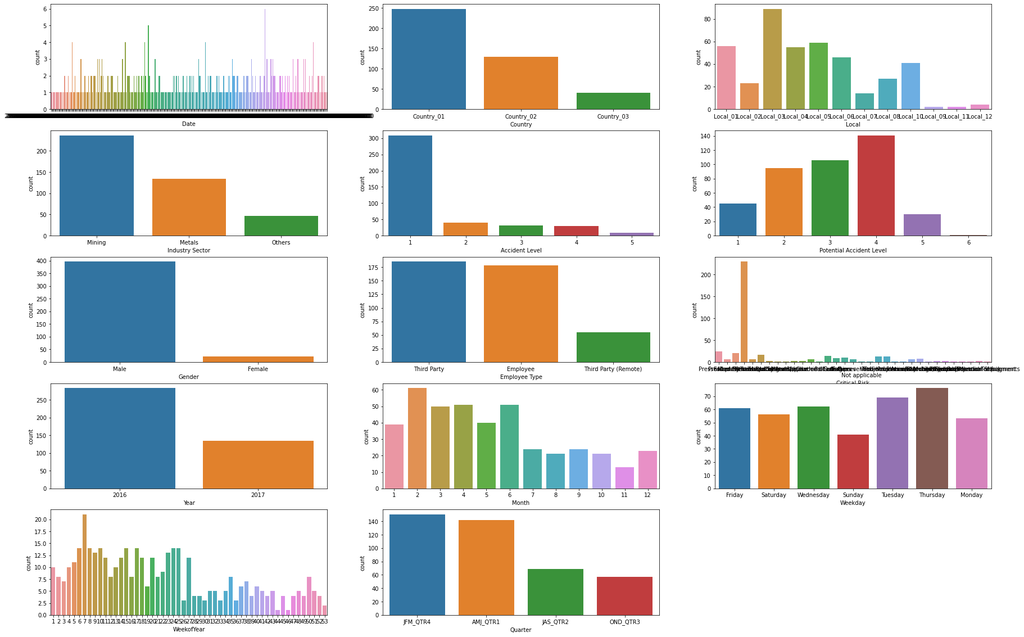

```python
plt.figure(figsize= (30,20))               # Set the figure size
pos = 1                                    # a variable to manage the position of the subplot in the overall plot
for feature in safety_df.columns:                 # for-loop to iterate over every attribute whose distribution is to be visualized
    plt.subplot(5, 3, pos)                 # plot grid
    # Plot bar chart for categorical label 'status'
    sns.countplot(safety_df[feature])
    pos += 1                            # to plot over the grid one by one
```

```python
safety_data['Critical Risk'].unique()
```

```
array(['Pressed', 'Pressurized Systems', 'Manual Tools', 'Others',
       'Fall prevention (same level)', 'Chemical substances',
       'Liquid Metal', 'Electrical installation', 'Confined space',
       'Pressurized Systems / Chemical Substances',
       'Blocking and isolation of energies', 'Suspended Loads', 'Poll',
       'Cut', 'Fall', 'Bees', 'Fall prevention', '\nNot applicable',
       'Traffic', 'Projection', 'Venomous Animals', 'Plates',
       'Projection/Burning', 'remains of choco',
       'Vehicles and Mobile Equipment', 'Projection/Choco',
       'Machine Protection', 'Power lock', 'Burn',
       'Projection/Manual Tools', 'Individual protection equipment',
       'Electrical Shock', 'Projection of fragments'], dtype=object)
```

```python
safety_data.groupby(['Critical Risk'], sort=True).size()
```

```
Critical Risk
\nNot applicable                               1
Bees                                          10
Blocking and isolation of energies             3
Burn                                           1
Chemical substances                           17
Confined space                                 1
Cut                                           14
Electrical Shock                               2
Electrical installation                        1
Fall                                           9
Fall prevention                                6
Fall prevention (same level)                   7
Individual protection equipment                1
Liquid Metal                                   3
Machine Protection                             2
Manual Tools                                  20
Others                                       229
Plates                                         1
Poll                                           1
Power lock                                     3
Pressed                                       24
Pressurized Systems                            7
Pressurized Systems / Chemical Substances      3
Projection                                    13
Projection of fragments                        1
Projection/Burning                             1
Projection/Choco                               1
Projection/Manual Tools                        1
Suspended Loads                                6
Traffic                                        1
Vehicles and Mobile Equipment                  8
Venomous Animals                              13
remains of choco                               7
dtype: int64
```

```python
risk_type = safety_data.groupby('Critical Risk').count().sort_values(by=['Date'], ascending = True).reset_index()
```

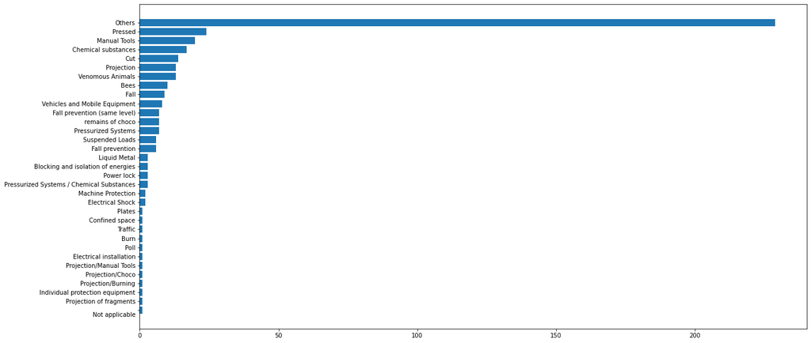

```python
plt.figure(figsize=(20,10))
plt.barh(risk_type['Critical Risk'],risk_type['Date'])
plt.xticks(rotation = 'horizontal')
```

#### Understand the countrywise Injuries or Accidents in Plants

```python
import plotly.express as px
```

```python
fig = px.pie(safety_data, names='Country', template='seaborn')
fig.update_traces(rotation=45, pull=[0.1,0.01,0.1,0.01,0.1], textinfo="percent+label", showlegend=True)
fig.show()
```

[interactive chart not shown]

It shows Couontry_01 is highly impacted followed by Country_02 and Country_03.

Approximatelly 60% of accidents happends in Country_01. We need to understand what type of accidents happen in Country_01

##### Understand the Genderwise Injuries or Accidents in Plants

```python
fig = px.pie(safety_data, names='Gender', template='seaborn')
fig.update_traces(rotation=45, pull=[0.1,0.01,0.1,0.01,0.1],textinfo="percent+label", showlegend=True)
fig.show()
```

[interactive chart not shown]

It shows 95% of plant accidents or injuries happened to Male employees

```python
fig = px.pie(safety_data, names='Accident Level', template='seaborn')
fig.update_traces(rotation=45, pull=[0.1,0.01,0.1,0.01,0.1],textinfo="percent+label", showlegend=True)
fig.show()
```

[interactive chart not shown]

Accident Level I occured 73% of times

```python
fig = px.pie(safety_data, names='Potential Accident Level', template='seaborn')
fig.update_traces(rotation=45, pull=[0.1,0.01,0.1,0.01,0.1],textinfo="percent+label", showlegend=True)
fig.show()
```

[interactive chart not shown]

But, potential accident level shows Type IV ie more severe accident (33%), that means 1/3 of accident could be potenial to have Type-IV accident level

### EDA - Multivariate Analysis

```python
safety_data.groupby(['Country']).size()
```

```
Country
Country_01    248
Country_02    129
Country_03     41
dtype: int64
```

Country_01 has appx 60% of incidents

```python
safety_data.groupby(['Country', 'Accident Level']).size()
```

```
Country     Accident Level
Country_01  1                 177
            2                  19
            3                  21
            4                  23
            5                   8
Country_02  1                  98
            2                  19
            3                   7
            4                   5
Country_03  1                  34
            2                   2
            3                   3
            4                   2
dtype: int64
```

42% of overall incidents was in Accident Level I and happend in Country_01

```python
def chart_Vs_AccLevel(data, feature):
    fig = plt.figure(figsize = (20, 10))
    ax = fig.add_subplot(121)
    sns.countplot(x = feature, data = data, ax = ax, orient = 'v',
                  hue = 'Accident Level').set_title(feature.capitalize() +' count plot by Accident Level', fontsize = 13)

    plt.legend(labels = data['Accident Level'].unique())
    plt.xticks(rotation = 90)

    ax = fig.add_subplot(122)
    sns.countplot(x = feature, data = data, ax = ax, orient = 'v',
                  hue = 'Potential Accident Level').set_title(feature.capitalize() +' count plot by Potential Accident Level',
                                                                      fontsize = 13)
    plt.legend(labels = data['Potential Accident Level'].unique())
    plt.xticks(rotation = 90)
    return plt.show()
```

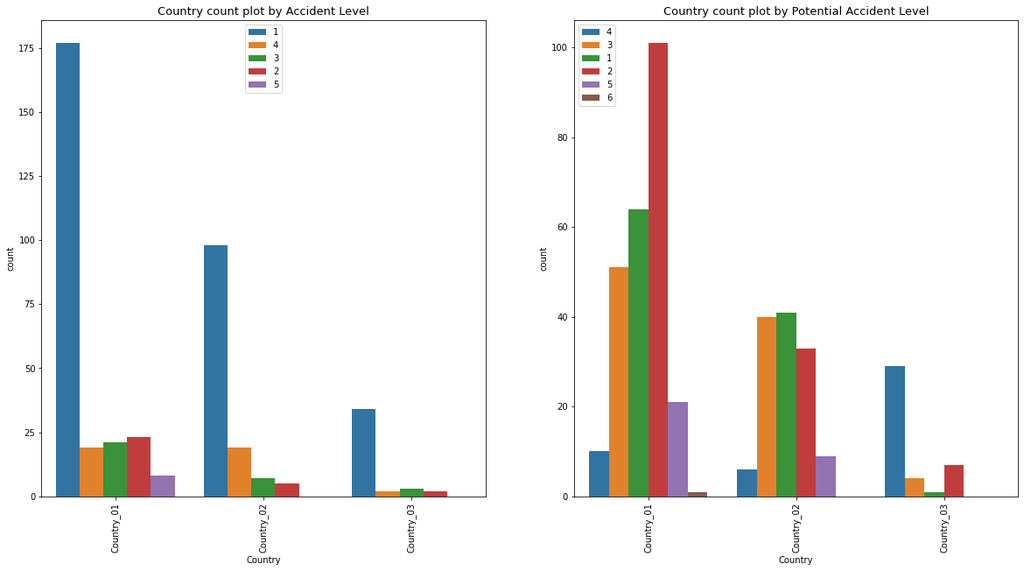

```python
chart_Vs_AccLevel(safety_data, 'Country')
```

Accident Level:

Potential Accident Level:

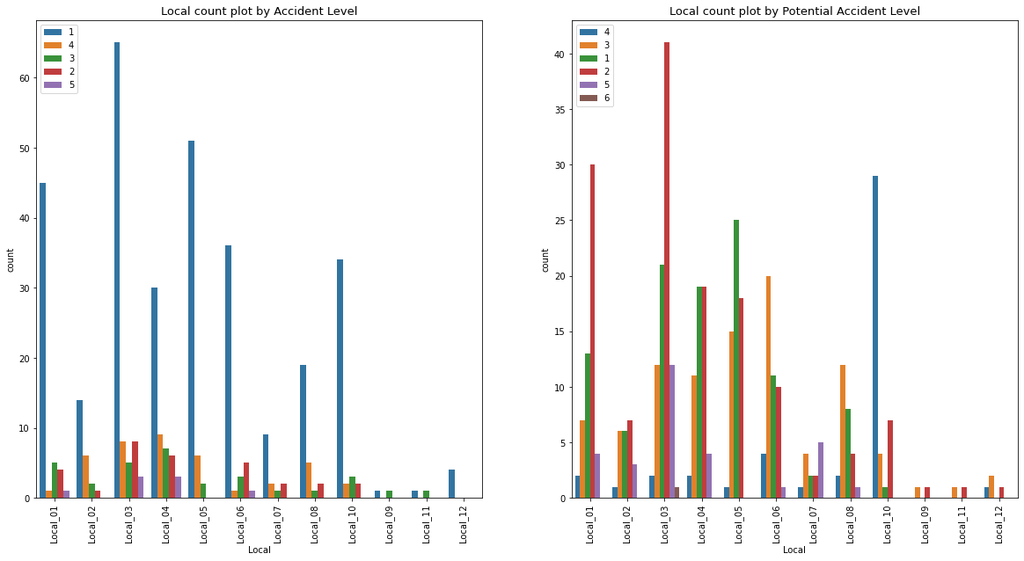

```python
chart_Vs_AccLevel(safety_data, 'Local')
```

```python
#safety_data.groupby(['Country', 'Local', 'Accident Level']).size()
safety_data.groupby(['Country', 'Local']).size()
```

```
Country     Local
Country_01  Local_01    56
            Local_03    89
            Local_04    55
            Local_06    46
            Local_11     2
Country_02  Local_02    23
            Local_05    59
            Local_07    14
            Local_08    27
            Local_09     2
            Local_12     4
Country_03  Local_10    41
dtype: int64
```

Location_03 which is in Country_01 has experienced more accidents followed by Location_05 in Country_02

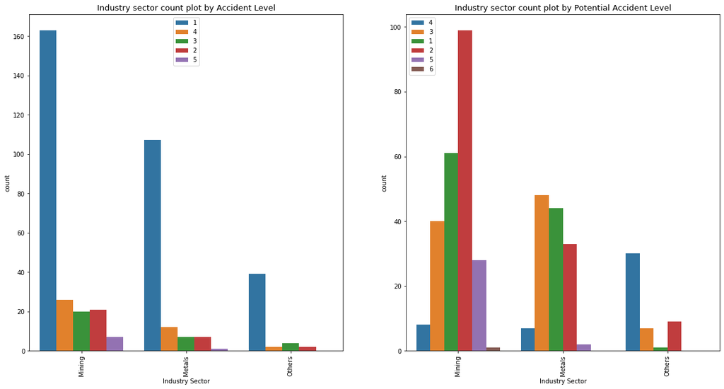

```python
chart_Vs_AccLevel(safety_data,'Industry Sector')
```

```python
#safety_data.groupby(['Country', 'Accident Level', 'Local', 'Industry Sector']).size()
safety_data.groupby(['Country', 'Local', 'Industry Sector']).size()
```

```
Country     Local     Industry Sector
Country_01  Local_01  Mining             56
            Local_03  Mining             89
            Local_04  Mining             55
            Local_06  Metals             46
            Local_11  Others              2
Country_02  Local_02  Mining             23
            Local_05  Metals             59
            Local_07  Mining             14
            Local_08  Metals             27
            Local_09  Metals              2
            Local_12  Others              4
Country_03  Local_10  Others             41
dtype: int64
```

1. In Country_01, Appx 80% of accidents occured in Mining industry sector in the location_01, location_03, location_04. Rest of the 20% occured in Metals and Others
2. In Country_02, appx 60% of accident occured in Metals in the location_05, location_08 and location_09. Rest of 40% occured in Mining and other areas
3. In Country_03, 100% of accidents occured in 'Other' industry sectors

**In Country_01, it shows clearly "Mining Industry Sector" is the highly accident prone area and Safety preventive actions to be taken care......... In Country_02, "Metals Industry Sector" has experienced more accidents**

```python
safety_data.groupby(['Country', 'Critical Risk']).size()
```

```
Country     Critical Risk
Country_01  Blocking and isolation of energies             1
            Chemical substances                            4
            Cut                                            5
            Electrical Shock                               2
            Electrical installation                        1
            Fall                                           6
            Fall prevention                                3
            Fall prevention (same level)                   5
            Individual protection equipment                1
            Machine Protection                             1
            Manual Tools                                   7
            Others                                       169
            Plates                                         1
            Power lock                                     3
            Pressed                                        9
            Pressurized Systems                            1
            Pressurized Systems / Chemical Substances      2
            Projection                                     9
            Projection of fragments                        1
            Projection/Manual Tools                        1
            Suspended Loads                                3
            Vehicles and Mobile Equipment                  7
            remains of choco                               6
Country_02  \nNot applicable                               1
            Blocking and isolation of energies             2
            Burn                                           1
            Chemical substances                           13
            Confined space                                 1
            Cut                                            9
            Fall                                           1
            Fall prevention                                2
            Fall prevention (same level)                   2
            Liquid Metal                                   3
            Machine Protection                             1
            Manual Tools                                  12
            Others                                        45
            Pressed                                       15
            Pressurized Systems                            6
            Pressurized Systems / Chemical Substances      1
            Projection                                     4
            Projection/Burning                             1
            Suspended Loads                                3
            Traffic                                        1
            Vehicles and Mobile Equipment                  1
            Venomous Animals                               3
            remains of choco                               1
Country_03  Bees                                          10
            Fall                                           2
            Fall prevention                                1
            Manual Tools                                   1
            Others                                        15
            Poll                                           1
            Projection/Choco                               1
            Venomous Animals                              10
dtype: int64
```

In Country_01 and Country_02, majority of the critical risks are mentioned as "Others". But in Country_03, risks like 'Bees and Venomous Animals' are given but the 'Industry sector' is not clear as it is mentioned as "Others"

```python
safety_data.groupby(['Country', 'Gender','Accident Level']).size()
```

```
Country     Gender  Accident Level
Country_01  Female  1                   6
                    3                   1
            Male    1                 171
                    2                  19
                    3                  20
                    4                  23
                    5                   8
Country_02  Female  1                  12
                    2                   3
            Male    1                  86
                    2                  16
                    3                   7
                    4                   5
Country_03  Male    1                  34
                    2                   2
                    3                   3
                    4                   2
dtype: int64
```

Male employees were involved in 41% of overall incidents/accidents in the categroy of Accident Level I and occured in Country_01

```python
safety_data.groupby(['Country', 'Local', 'Industry Sector','Employee Type', 'Gender']).size()
```

```
Country     Local     Industry Sector  Employee Type         Gender
Country_01  Local_01  Mining           Employee              Male      23
                                       Third Party           Male      30
                                       Third Party (Remote)  Male       3
            Local_03  Mining           Employee              Female     1
                                                             Male      29
                                       Third Party           Female     1
                                                             Male      47
                                       Third Party (Remote)  Female     1
                                                             Male      10
            Local_04  Mining           Employee              Male      14
                                       Third Party           Female     1
                                                             Male      39
                                       Third Party (Remote)  Male       1
            Local_06  Metals           Employee              Male      18
                                       Third Party           Female     2
                                                             Male      18
                                       Third Party (Remote)  Male       8
            Local_11  Others           Employee              Female     1
                                                             Male       1
Country_02  Local_02  Mining           Employee              Male      11
                                       Third Party           Male       1
                                       Third Party (Remote)  Male      11
            Local_05  Metals           Employee              Female     2
                                                             Male      35
                                       Third Party           Female     2
                                                             Male       7
                                       Third Party (Remote)  Female     3
                                                             Male      10
            Local_07  Mining           Employee              Male      11
                                       Third Party           Female     1
                                       Third Party (Remote)  Male       2
            Local_08  Metals           Employee              Female     1
                                                             Male      18
                                       Third Party           Female     2
                                       Third Party (Remote)  Female     1
                                                             Male       5
            Local_09  Metals           Employee              Male       2
            Local_12  Others           Employee              Female     3
                                                             Male       1
Country_03  Local_10  Others           Employee              Male       7
                                       Third Party           Male      34
dtype: int64
```

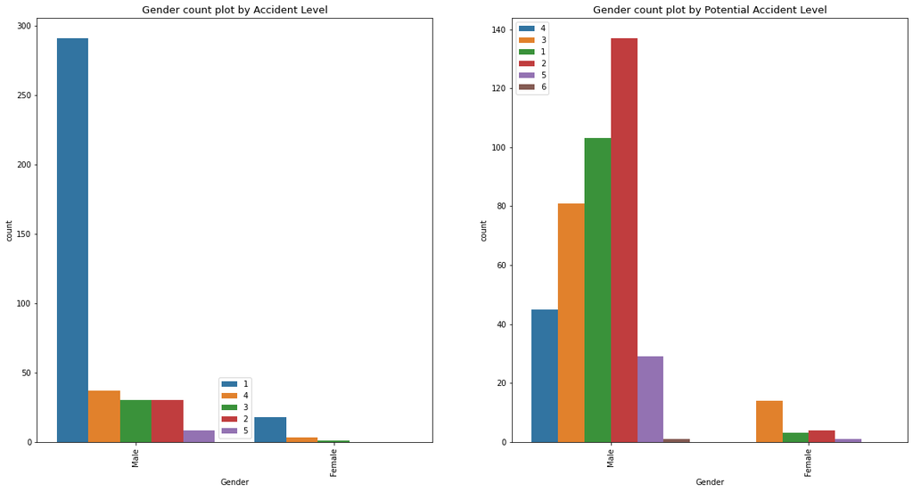

```python
chart_Vs_AccLevel(safety_data, 'Gender')
```

```python
safety_data.groupby(['Country', 'Local', 'Industry Sector','Employee Type']).size()
```

```
Country     Local     Industry Sector  Employee Type
Country_01  Local_01  Mining           Employee                23
                                       Third Party             30
                                       Third Party (Remote)     3
            Local_03  Mining           Employee                30
                                       Third Party             48
                                       Third Party (Remote)    11
            Local_04  Mining           Employee                14
                                       Third Party             40
                                       Third Party (Remote)     1
            Local_06  Metals           Employee                18
                                       Third Party             20
                                       Third Party (Remote)     8
            Local_11  Others           Employee                 2
Country_02  Local_02  Mining           Employee                11
                                       Third Party              1
                                       Third Party (Remote)    11
            Local_05  Metals           Employee                37
                                       Third Party              9
                                       Third Party (Remote)    13
            Local_07  Mining           Employee                11
                                       Third Party              1
                                       Third Party (Remote)     2
            Local_08  Metals           Employee                19
                                       Third Party              2
                                       Third Party (Remote)     6
            Local_09  Metals           Employee                 2
            Local_12  Others           Employee                 4
Country_03  Local_10  Others           Employee                 7
                                       Third Party             34
dtype: int64
```

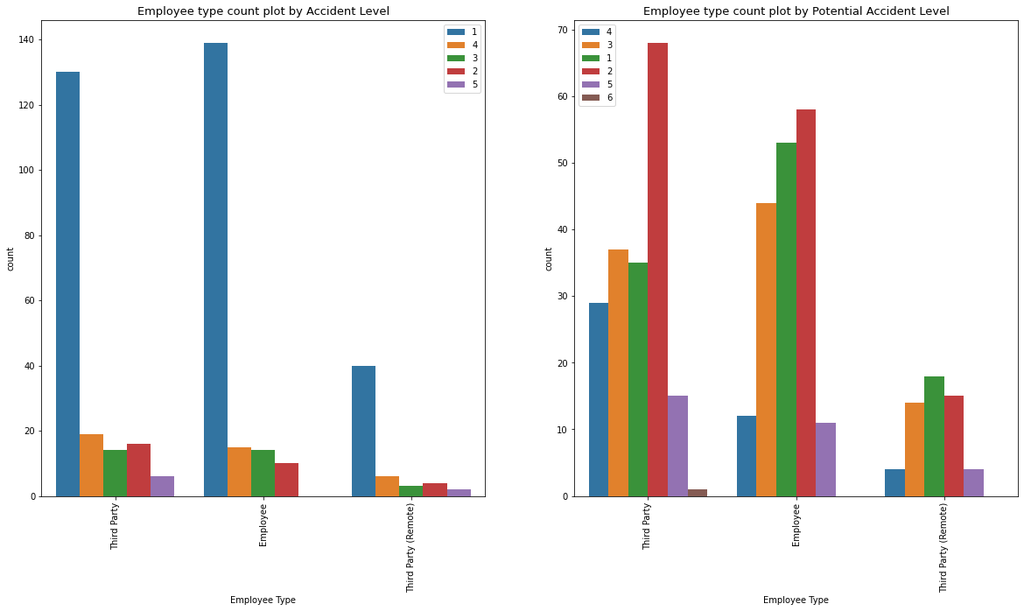

```python
chart_Vs_AccLevel(safety_data,'Employee Type')
```

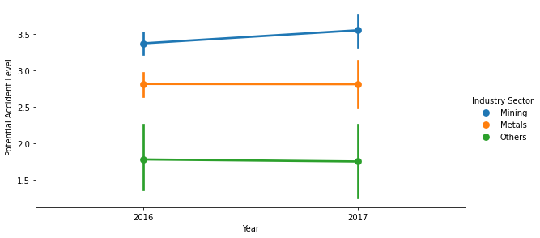

```python
sns.factorplot(x='Year', y='Potential Accident Level', data=safety_data, hue='Industry Sector', aspect=2, size=4)
```

Factor plot shows potential accidents remain the same for both the years. Only Mining has slight increase

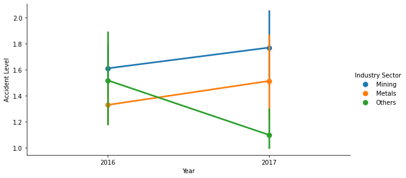

```python
sns.factorplot(x='Year', y='Accident Level', data=safety_data, hue='Industry Sector', aspect=2, size=4)
```

Factor plot shows, Accident level significantly reduced in other sectors. But, there is a slight increase in 2017 as comparted to 2016

### Analysis of Features

```python
piv_accident_level =safety_data.pivot_table(index='Month', columns=[ 'Year','Accident Level'], aggfunc='count')['Country']
```

```python
piv_accident_level
```

| Year Accident Level Month | 2016 1 | 2016 2 | 2016 3 | 2016 4 | 2016 5 | 2017 1 | 2017 2 | 2017 3 | 2017 4 | 2017 5 |
| --- | --- | --- | --- | --- | --- | --- | --- | --- | --- | --- |
| 1 | 11.0 | NaN | NaN | 1.0 | NaN | 21.0 | 2.0 | 2.0 | 1.0 | 1.0 |
| 2 | 23.0 | 4.0 | 2.0 | 1.0 | 1.0 | 19.0 | 5.0 | 2.0 | 4.0 | NaN |
| 3 | 24.0 | 4.0 | 3.0 | 3.0 | NaN | 10.0 | 3.0 | NaN | NaN | 3.0 |
| 4 | 23.0 | 1.0 | 3.0 | 1.0 | NaN | 20.0 | 1.0 | NaN | 2.0 | NaN |
| 5 | 23.0 | 2.0 | NaN | 1.0 | NaN | 8.0 | 1.0 | 1.0 | 3.0 | 1.0 |
| 6 | 26.0 | 1.0 | NaN | 3.0 | 1.0 | 15.0 | 2.0 | 2.0 | 1.0 | NaN |
| 7 | 11.0 | 1.0 | 4.0 | 2.0 | 1.0 | 5.0 | NaN | NaN | NaN | NaN |
| 8 | 15.0 | 3.0 | 2.0 | 1.0 | NaN | NaN | NaN | NaN | NaN | NaN |
| 9 | 18.0 | 3.0 | 2.0 | 1.0 | NaN | NaN | NaN | NaN | NaN | NaN |
| 10 | 11.0 | 4.0 | 4.0 | 2.0 | NaN | NaN | NaN | NaN | NaN | NaN |
| 11 | 9.0 | 1.0 | 1.0 | 2.0 | NaN | NaN | NaN | NaN | NaN | NaN |
| 12 | 17.0 | 2.0 | 3.0 | 1.0 | NaN | NaN | NaN | NaN | NaN | NaN |

```python
piv_potential_level =safety_data.pivot_table(index='Month', columns=[ 'Year','Potential Accident Level'], aggfunc='count')['Country']
piv_potential_level
```

| Year Potential Accident Level Month | 2016 1 | 2016 2 | 2016 3 | 2016 4 | 2016 5 | 2017 1 | 2017 2 | 2017 3 | 2017 4 | 2017 5 | 2017 6 |
| --- | --- | --- | --- | --- | --- | --- | --- | --- | --- | --- | --- |
| 1 | 1.0 | 1.0 | 5.0 | 5.0 | NaN | 3.0 | 2.0 | 11.0 | 10.0 | NaN | 1.0 |
| 2 | 2.0 | 9.0 | 6.0 | 10.0 | 4.0 | 4.0 | 5.0 | 9.0 | 9.0 | 3.0 | NaN |
| 3 | 1.0 | 7.0 | 11.0 | 13.0 | 2.0 | 5.0 | NaN | 2.0 | 3.0 | 6.0 | NaN |
| 4 | NaN | 6.0 | 10.0 | 9.0 | 3.0 | 4.0 | 7.0 | 4.0 | 6.0 | 2.0 | NaN |
| 5 | 5.0 | 3.0 | 9.0 | 8.0 | 1.0 | 2.0 | 3.0 | 1.0 | 5.0 | 3.0 | NaN |
| 6 | 10.0 | 4.0 | 9.0 | 6.0 | 2.0 | 1.0 | 5.0 | 3.0 | 11.0 | NaN | NaN |
| 7 | NaN | 6.0 | 2.0 | 9.0 | 2.0 | NaN | 4.0 | 1.0 | NaN | NaN | NaN |
| 8 | 1.0 | 7.0 | 7.0 | 6.0 | NaN | NaN | NaN | NaN | NaN | NaN | NaN |
| 9 | 4.0 | 9.0 | 4.0 | 7.0 | NaN | NaN | NaN | NaN | NaN | NaN | NaN |
| 10 | NaN | 4.0 | 5.0 | 12.0 | NaN | NaN | NaN | NaN | NaN | NaN | NaN |
| 11 | 2.0 | 5.0 | 1.0 | 4.0 | 1.0 | NaN | NaN | NaN | NaN | NaN | NaN |
| 12 | NaN | 8.0 | 6.0 | 8.0 | 1.0 | NaN | NaN | NaN | NaN | NaN | NaN |

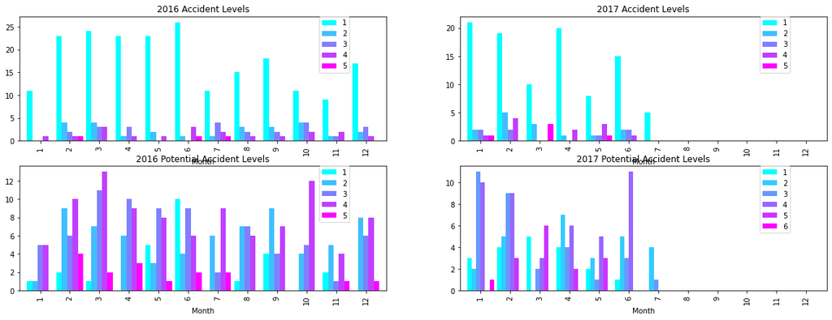

```python
fig = plt.figure(figsize=(20,7))
ax = fig.add_subplot(2, 2, 1)
piv_accident_level[2016].plot(kind='bar', ax=ax, width=0.9, cmap='cool', title='2016 Accident Levels')
plt.legend(bbox_to_anchor=(0.9, 1), loc=1, borderaxespad=0.)

ax = fig.add_subplot(2, 2, 2)
piv_accident_level[2017].plot(kind='bar', ax=ax, width=0.9, cmap='cool', title='2017 Accident Levels')
plt.legend(bbox_to_anchor=(0.9, 1), loc=1, borderaxespad=0.)

ax = fig.add_subplot(2, 2, 3)
piv_potential_level[2016].plot(kind='bar', ax=ax, width=0.9, cmap='cool', title='2016 Potential Accident Levels')
plt.legend(bbox_to_anchor=(0.9, 1), loc=1, borderaxespad=0.)

ax = fig.add_subplot(2, 2, 4)
piv_potential_level[2017].plot(kind='bar', ax=ax, width=0.9, cmap='cool', title='2017 Potential Accident Levels')
plt.legend(bbox_to_anchor=(0.9, 1), loc=1, borderaxespad=0.)
```

Above bar chart shows month-wise accident level and potential accident level distribution. In the year 2017, we have only data for 7 months.

This clearly shows, accident level is reduced when compared to potential accident level.

Most of the Accidents are Level I and occurred thru out the year eventhough the potential level of accidents is high.

### Accident Level Vs Potential Accident Level

```python
import holoviews as hv
import holoviews as hv
from holoviews import opts
```

```python
hv.extension('bokeh')

ac_level_cnt = np.round(safety_data['Accident Level'].value_counts(normalize=True) * 100)
pot_ac_level_cnt = np.round(safety_data['Potential Accident Level'].value_counts(normalize=True) * 100, decimals=1)
ac_pot = pd.concat([ac_level_cnt, pot_ac_level_cnt], axis=1,sort=False).fillna(0).rename(columns={'Accident Level':'Accident', 'Potential Accident Level':'Potential'})
ac_pot = pd.melt(ac_pot.reset_index(), ['index']).rename(columns={'index':'Severity', 'variable':'Levels'})
hv.Bars(ac_pot, ['Severity', 'Levels'], 'value').opts(opts.Bars(title="Accident Levels Count", width=700, height=300,tools=['hover'],\
                                                                show_grid=True,xrotation=45, ylabel="Percentage", yformatter='%d%%'))
```

[interactive chart not shown]

This bar chart shows the comparison of Accident Level Vs Potential Accident Level

1. Type 1 - More number of accident happened than potential accident level assumed or predicted
2. Type 2 - Less number of accident happened than potential accident level assumed or predicted
3. Type 3 - Less number of accident happened than potential accident level assumed or predicted
4. Type 4 - Less number of accident happened than potential accident level assumed or predicted
5. Type 5 - Less number of accident happened than potential accident level assumed or predicted
6. Type 6 - No accident happened as compared to predicted

## Key Takeaways/Observations from EDA

1. Reason for Country_01 has more number of accidents
2. Reason for more male and 3rd party are affected by accidents? Are they trained or preventive actions taken?
3. Reason for Location_03 is more dangerous place to work.
4. Reason for more accidents on Thursday and JFM Quarter (Last Quarter of the year)

## Reason for Country_01 has more number of accidents: Mining Industry

In Country_01, Appx 80% of accidents occured in Mining industry sector. Mining Industry operats in location_01, location_03, location_04.

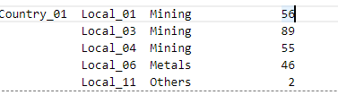

## Reason for more Male and 3rd party are affected by accidents :

There could reasons like

1. Significantly more number of male and 3rd party employees working in Mining Industry where the most number of accidents happend.
2. Female employees took safety preventive actions. Hence, accidents not reported.

With the limited data, it would be difficult to identify the reason

### Are they trained or preventive actions taken :

Yes, Data shows accident level is reduced as compared to potential accident levels. Type IV accidents happended in Country_01 (Mining) could be prevented

## Reason for Location_03 is more dangerous place to work

Industry Sector in this region is Mining

## Reason for more accidents on Thursday and JFM Quarter (Last Quarter of the year)

```python
safety_data.groupby(['Country', 'Local', 'Industry Sector','Quarter']).size()
```

```
Country     Local     Industry Sector  Quarter
Country_01  Local_01  Mining           AMJ_QTR1    23
                                       JAS_QTR2     5
                                       JFM_QTR4    23
                                       OND_QTR3     5
            Local_03  Mining           AMJ_QTR1    26
                                       JAS_QTR2    16
                                       JFM_QTR4    33
                                       OND_QTR3    14
            Local_04  Mining           AMJ_QTR1    17
                                       JAS_QTR2     7
                                       JFM_QTR4    18
                                       OND_QTR3    13
            Local_06  Metals           AMJ_QTR1    11
                                       JAS_QTR2    10
                                       JFM_QTR4    20
                                       OND_QTR3     5
            Local_11  Others           AMJ_QTR1     1
                                       JAS_QTR2     1
Country_02  Local_02  Mining           AMJ_QTR1     8
                                       JAS_QTR2     3
                                       JFM_QTR4     8
                                       OND_QTR3     4
            Local_05  Metals           AMJ_QTR1    21
                                       JAS_QTR2    14
                                       JFM_QTR4    17
                                       OND_QTR3     7
            Local_07  Mining           AMJ_QTR1     5
                                       JAS_QTR2     2
                                       JFM_QTR4     6
                                       OND_QTR3     1
            Local_08  Metals           AMJ_QTR1     5
                                       JAS_QTR2     4
                                       JFM_QTR4    12
                                       OND_QTR3     6
            Local_09  Metals           AMJ_QTR1     1
                                       JAS_QTR2     1
            Local_12  Others           AMJ_QTR1     2
                                       JAS_QTR2     2
Country_03  Local_10  Others           AMJ_QTR1    22
                                       JAS_QTR2     4
                                       JFM_QTR4    13
                                       OND_QTR3     2
dtype: int64
```

```python
safety_data.groupby(['Weekday','Country', 'Industry Sector']).size()
```

```
Weekday    Country     Industry Sector
Friday     Country_01  Metals              8
                       Mining             35
           Country_02  Metals             12
                       Mining              5
           Country_03  Others              1
Monday     Country_01  Metals              7
                       Mining             22
                       Others              1
           Country_02  Metals             17
                       Mining              4
           Country_03  Others              2
Saturday   Country_01  Metals              2
                       Mining             35
           Country_02  Metals              4
                       Mining              9
           Country_03  Others              6
Sunday     Country_01  Metals              9
                       Mining             23
           Country_02  Metals              6
                       Mining              2
           Country_03  Others              1
Thursday   Country_01  Metals              6
                       Mining             32
           Country_02  Metals             19
                       Mining              5
                       Others              2
           Country_03  Others             12
Tuesday    Country_01  Metals              6
                       Mining             28
                       Others              1
           Country_02  Metals             15
                       Mining              8
                       Others              2
           Country_03  Others              9
Wednesday  Country_01  Metals              8
                       Mining             25
           Country_02  Metals             15
                       Mining              4
           Country_03  Others             10
dtype: int64
```

Based on the data, accident count is more on 'Friday' and 'Saturday' in the Mining Sector followed by Thursday

```python
safety_data.info()
```

```
<class 'pandas.core.frame.DataFrame'>
Int64Index: 418 entries, 0 to 424
Data columns (total 16 columns):
 #   Column                    Non-Null Count  Dtype
---  ------                    --------------  -----
 0   Date                      418 non-null    datetime64[ns]
 1   Country                   418 non-null    object
 2   Local                     418 non-null    object
 3   Industry Sector           418 non-null    object
 4   Accident Level            418 non-null    int64
 5   Potential Accident Level  418 non-null    int64
 6   Gender                    418 non-null    object
 7   Employee Type             418 non-null    object
 8   Critical Risk             418 non-null    object
 9   Description               418 non-null    object
 10  Description_length        418 non-null    int64
 11  Year                      418 non-null    int64
 12  Month                     418 non-null    int64
 13  Weekday                   418 non-null    object
 14  WeekofYear                418 non-null    int64
 15  Quarter                   418 non-null    object
dtypes: datetime64[ns](1), int64(6), object(9)
memory usage: 75.5+ KB
```

```python
#Take a copy and apply encoding
safety_data_encod = copy.deepcopy(safety_data)
```

### Feature Selection and Importance

1. Chi2
2. Correlation with HeatMap
3. Feature Importance using XGBoost Classifier

```python
safety_data_encod['Country'] = LabelEncoder().fit_transform(safety_data_encod['Country'])
safety_data_encod['Local'] = LabelEncoder().fit_transform(safety_data_encod['Local'])
safety_data_encod['Industry Sector'] = LabelEncoder().fit_transform(safety_data_encod['Industry Sector'])
safety_data_encod['Gender'] = LabelEncoder().fit_transform(safety_data_encod['Gender'])
safety_data_encod['Employee Type'] = LabelEncoder().fit_transform(safety_data_encod['Employee Type'])
safety_data_encod['Critical Risk'] = LabelEncoder().fit_transform(safety_data_encod['Critical Risk'])
safety_data_encod['Quarter'] = LabelEncoder().fit_transform(safety_data_encod['Quarter'])
```

```python
safety_data_encod['Weekday'].unique()
```

```
array(['Friday', 'Saturday', 'Wednesday', 'Sunday', 'Tuesday', 'Thursday',
       'Monday'], dtype=object)
```

```python
## Change the object/string reporesentation of Weekday to Integers
weekday_t = {'Monday': 1, 'Tuesday': 2,'Wednesday': 3 , 'Thursday' : 4, 'Friday': 5, 'Saturday' : 6, 'Sunday' : 7}
safety_data_encod['Weekday'] = pd.Series([weekday_t[x] for x in safety_data_encod['Weekday']], index=safety_data_encod.index)
```

```python
safety_data_encod['Weekday'].unique()
```

```
array([5, 6, 3, 7, 2, 4, 1])
```

```python
safety_data_encod.info()
```

```
<class 'pandas.core.frame.DataFrame'>
Int64Index: 418 entries, 0 to 424
Data columns (total 16 columns):
 #   Column                    Non-Null Count  Dtype
---  ------                    --------------  -----
 0   Date                      418 non-null    datetime64[ns]
 1   Country                   418 non-null    int64
 2   Local                     418 non-null    int64
 3   Industry Sector           418 non-null    int64
 4   Accident Level            418 non-null    int64
 5   Potential Accident Level  418 non-null    int64
 6   Gender                    418 non-null    int64
 7   Employee Type             418 non-null    int64
 8   Critical Risk             418 non-null    int64
 9   Description               418 non-null    object
 10  Description_length        418 non-null    int64
 11  Year                      418 non-null    int64
 12  Month                     418 non-null    int64
 13  Weekday                   418 non-null    int64
 14  WeekofYear                418 non-null    int64
 15  Quarter                   418 non-null    int64
dtypes: datetime64[ns](1), int64(14), object(1)
memory usage: 75.5+ KB
```

```python
safety_data_encod = safety_data_encod.drop(columns=['Description_length','Month','Year','WeekofYear'], axis=1)
```

```python
from sklearn.feature_selection import f_classif, chi2, mutual_info_classif
from statsmodels.stats.multicomp import pairwise_tukeyhsd

X = safety_data_encod.drop(columns=['Accident Level', 'Potential Accident Level','Date', 'Description'], axis=1)
```

```python
y = safety_data_encod['Potential Accident Level']
```

#### 1. Univariate Selection Statistical tests - chi2

To select features that have the strongest relationship with the output variable. chi-squared (chi²) statistical test for non-negative features to select the best features

```python
from sklearn.feature_selection import SelectKBest
from sklearn.feature_selection import chi2
```

```python
#apply SelectKBest class to extract top best features
bestfeatures = SelectKBest(score_func=chi2, k=7)
fit = bestfeatures.fit(X,y)
dfscores = pd.DataFrame(fit.scores_)
dfcolumns = pd.DataFrame(X.columns)
#concat two dataframes for better visualization
featureScores = pd.concat([dfcolumns,dfscores],axis=1)
featureScores.columns = ['Specs','Score']  #naming the dataframe columns
print(featureScores.nlargest(7,'Score'))  #print 10 best features
```

```
             Specs       Score
1            Local  207.499104
0          Country   88.305664
5    Critical Risk   42.155724
2  Industry Sector   41.679364
7          Quarter    5.163549
6          Weekday    2.971151
4    Employee Type    1.424797
```

#### 2. Correlation Matrix with Heatmap

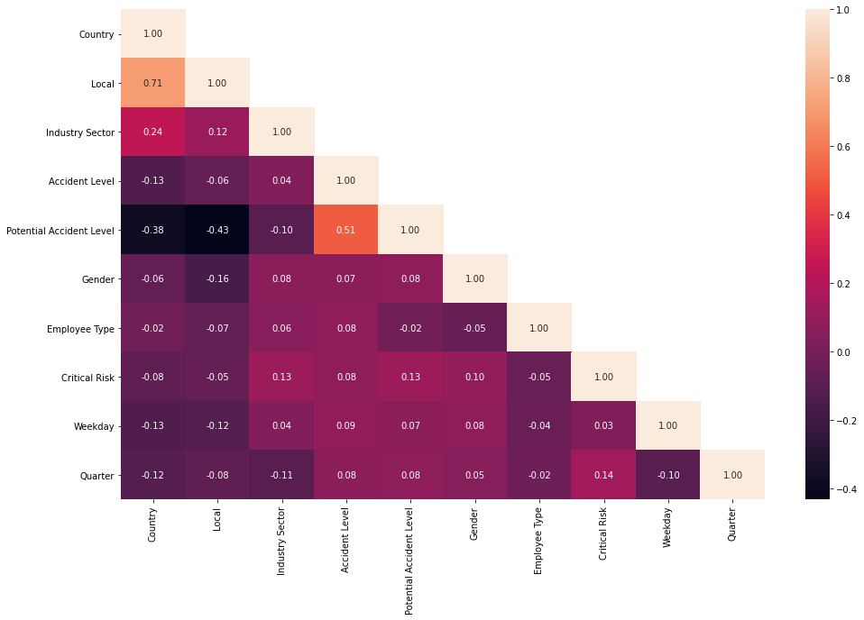

```python
# Correlation matrix

corr1 = safety_data_encod.corr()
mask1=np.zeros_like(corr1);
mask1[np.triu_indices_from(mask1, 1)] = True

plt.figure(figsize=(16,10))
sns.heatmap(corr1,annot=True, fmt = '.2f', mask=mask1)
```

Here are the observations:

1. +ve correlation between Potential Accident Level and Accident Level (0.51)
2. +ve Correlation between Critical Risk and Quarter (0.14). There could be reason that certain work is done in particular quarter
3. Critical Risk has +ve correlation between Industry Sector, Accident Level, Potential Level, Gender,
4. Gender and Employee type has +ve Industry sector, Accident Level
5. Country has high +ve(0.71) correlation to Local and Industry Sector (0.24)

#### Feature Importance using XGBOOST

```
[0.3495127  0.11577629 0.16157305 0.12624584 0.04973182 0.06952989
 0.06389433 0.06373607]
```

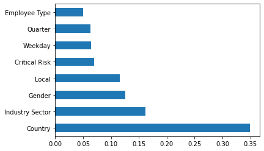

```python
from sklearn.datasets import make_classification
from xgboost import XGBClassifier
model = XGBClassifier()
model.fit(X,y)
print(model.feature_importances_) #use inbuilt class feature_importances of tree based classifiers
#plot graph of feature importances for better visualization
feat_importances = pd.Series(model.feature_importances_, index=X.columns)
feat_importances.nlargest(10).plot(kind='barh')
plt.show()
```

Irrelevant or partially relevant features can negatively impact model performance. Feature selection and Data cleaning should be the first and most important step of your model designing. Feature Selection is the process where you automatically or manually select those features which contribute most to your prediction variable

**Here, country has high feature importance followed by Industry Sector, Gender, Local, Critical Risk, Weekday, Quarter and Employee Type**

```python
safety_data_encod.info()
```

```
<class 'pandas.core.frame.DataFrame'>
Int64Index: 418 entries, 0 to 424
Data columns (total 12 columns):
 #   Column                    Non-Null Count  Dtype
---  ------                    --------------  -----
 0   Date                      418 non-null    datetime64[ns]
 1   Country                   418 non-null    int64
 2   Local                     418 non-null    int64
 3   Industry Sector           418 non-null    int64
 4   Accident Level            418 non-null    int64
 5   Potential Accident Level  418 non-null    int64
 6   Gender                    418 non-null    int64
 7   Employee Type             418 non-null    int64
 8   Critical Risk             418 non-null    int64
 9   Description               418 non-null    object
 10  Weekday                   418 non-null    int64
 11  Quarter                   418 non-null    int64
dtypes: datetime64[ns](1), int64(10), object(1)
memory usage: 62.5+ KB
```

```python
#Take a copy for creating featured data for ML
safety_data_ml = copy.deepcopy(safety_data)
safety_data_nlp = copy.deepcopy(safety_data)
```

### Pre-Processed Data for ML

```python
safety_data_ml['Country'] = LabelEncoder().fit_transform(safety_data_ml['Country'])
safety_data_ml['Local'] = LabelEncoder().fit_transform(safety_data_ml['Local'])
safety_data_ml['Critical Risk'] = LabelEncoder().fit_transform(safety_data_ml['Critical Risk'])
```

```python
## Change the object/string reporesentation of Weekday to Integers
weekday_t    = {'Monday': 1, 'Tuesday': 2,'Wednesday': 3 , 'Thursday' : 4, 'Friday': 5, 'Saturday' : 6, 'Sunday' : 7}
emp_type_e   = {'Employee' : 1, 'Third Party' : 2, 'Third Party (Remote)' :3}
ind_sector_e = {'Mining' :1 , 'Metals' : 2 , 'Others': 3 }
gender_e     = { 'Male' : 1, 'Female':2}
quarter_e    = {'AMJ_QTR1': 1, 'JAS_QTR2' : 2, 'OND_QTR3' : 3, 'JFM_QTR4': 4}

safety_data_ml['Weekday'] = pd.Series([weekday_t[x] for x in safety_data_ml['Weekday']], index=safety_data_ml.index)
safety_data_ml['Employee Type'] = pd.Series([emp_type_e[x] for x in safety_data_ml['Employee Type']], index=safety_data_ml.index)
safety_data_ml['Industry Sector'] = pd.Series([ind_sector_e[x] for x in safety_data_ml['Industry Sector']], index=safety_data_ml.index)
safety_data_ml['Gender'] = pd.Series([gender_e[x] for x in safety_data_ml['Gender']], index=safety_data_ml.index)
safety_data_ml['Quarter'] = pd.Series([quarter_e[x] for x in safety_data_ml['Quarter']], index=safety_data_ml.index)
```

#### Based on Feature Importance - dropped the following fields

'Month', 'Year', 'WeekofYear'

```python
safety_data_ml = safety_data_ml.drop(columns=['Date','Month','Year','WeekofYear'], axis=1)
```

```python
column_names =['Country', 'Industry Sector', 'Gender' , 'Local' , 'Critical Risk', 'Weekday', 'Quarter', 'Employee Type', 'Description', 'Description_length', 'Accident Level', 'Potential Accident Level']
```

```python
safety_data_ml = safety_data_ml.reindex(columns=column_names)
```

```python
safety_data_ml.info()
```

```
<class 'pandas.core.frame.DataFrame'>
Int64Index: 418 entries, 0 to 424
Data columns (total 12 columns):
 #   Column                    Non-Null Count  Dtype
---  ------                    --------------  -----
 0   Country                   418 non-null    int64
 1   Industry Sector           418 non-null    int64
 2   Gender                    418 non-null    int64
 3   Local                     418 non-null    int64
 4   Critical Risk             418 non-null    int64
 5   Weekday                   418 non-null    int64
 6   Quarter                   418 non-null    int64
 7   Employee Type             418 non-null    int64
 8   Description               418 non-null    object
 9   Description_length        418 non-null    int64
 10  Accident Level            418 non-null    int64
 11  Potential Accident Level  418 non-null    int64
dtypes: int64(11), object(1)
memory usage: 62.5+ KB
```

### Pre-Processed Data for NLP

```python
safety_data_nlp.info()
```

```
<class 'pandas.core.frame.DataFrame'>
Int64Index: 418 entries, 0 to 424
Data columns (total 16 columns):
 #   Column                    Non-Null Count  Dtype
---  ------                    --------------  -----
 0   Date                      418 non-null    datetime64[ns]
 1   Country                   418 non-null    object
 2   Local                     418 non-null    object
 3   Industry Sector           418 non-null    object
 4   Accident Level            418 non-null    int64
 5   Potential Accident Level  418 non-null    int64
 6   Gender                    418 non-null    object
 7   Employee Type             418 non-null    object
 8   Critical Risk             418 non-null    object
 9   Description               418 non-null    object
 10  Description_length        418 non-null    int64
 11  Year                      418 non-null    int64
 12  Month                     418 non-null    int64
 13  Weekday                   418 non-null    object
 14  WeekofYear                418 non-null    int64
 15  Quarter                   418 non-null    object
dtypes: datetime64[ns](1), int64(6), object(9)
memory usage: 75.5+ KB
```

```python
safety_data_nlp = safety_data_nlp.drop(columns=['Date','Month','Year','WeekofYear'], axis=1)
```

```python
safety_data_nlp = safety_data_nlp.reindex(columns=column_names)
```

### Download the clean and feature Importance File for ML and NLP Processing

```python
filename_ml = 'safety_data_ml.csv'
filename_nlp = 'safety_data_nlp.csv'

safety_data_ml.to_csv(project_path+filename_ml, index = False)
safety_data_nlp.to_csv(project_path+filename_nlp, index = False)
```

# Milestone 2

## Step 1: NLP pre processing

List of NLP Pre-Processing

```python
import numpy as np
import multiprocessing as mp

import string
#import spacy
import en_core_web_sm
from nltk.tokenize import word_tokenize
from sklearn.base import TransformerMixin, BaseEstimator
```

```python
!pip install normalise
```

```
     |████████████████████████████████| 15.7MB 307kB/s
```

```python
import nltk
nltk.download('brown')
nltk.download('names')
```

```
True
```

```python
from normalise import normalise
nlp = en_core_web_sm.load()
```

```python
class TextPreprocessor(BaseEstimator, TransformerMixin):
    def __init__(self, n_jobs=1):
        self.n_jobs = n_jobs

    def fit(self, X, y=None):
        return self

    def transform(self, X, *_):
        X_copy = X.copy()

        # parallelize based on number of cores
        partitions = 1
        cores = mp.cpu_count()
        if self.n_jobs <= -1:
            partitions = cores
        elif self.n_jobs <= 0:
            return X_copy.apply(self._preprocess_text)
        else:
            partitions = min(self.n_jobs, cores)

        data_split = np.array_split(X_copy, partitions)
        pool = mp.Pool(cores)
        data = pd.concat(pool.map(self._preprocess_part, data_split))
        pool.close()
        pool.join()

        return data

    def _preprocess_part(self, part):
        return part.apply(self._preprocess_text)

    def _preprocess_text(self, text):
        normalized_text = self._normalize(text)
        doc = nlp(normalized_text)
        removed_punct = self._remove_punct(doc)
        removed_stop_words = self._remove_stop_words(removed_punct)
        return self._lemmatize(removed_stop_words)

    def _normalize(self, text):
        # some issues in normalise package
        try:
            return ' '.join(normalise(text, verbose=False))
        except:
            return text

    def _remove_punct(self, doc):
        return [t for t in doc if t.text not in string.punctuation]

    def _remove_stop_words(self, doc):
        return [t for t in doc if not t.is_stop]

    def _lemmatize(self, doc):
        return ' '.join([t.lemma_ for t in doc])
```

```python
safety_data_nlp['Description'] = TextPreprocessor(n_jobs=-1).transform(safety_data_nlp['Description'])
```

```python
safety_data_nlp.shape
```

```
(418, 12)
```

```python
safety_data_nlp['Description'].head()
```

```
0    remove drill rod Jumbo 08 maintenance   superv...
1    activation sodium sulphide pump   piping uncou...
2    sub station MILPO locate level   170 collabora...
3    9 45   approximately Nv   1880 CX 695 OB7   pe...
4    approximately 11 45 m   circumstance mechanic ...
Name: Description, dtype: object
```

```python
maximum = max(safety_data_nlp["Description"].str.split().apply(len))
```

```python
maximum
```

```
95
```

```python
len(safety_data_nlp['Description'][95].split())
```

```
37
```

```python
X_feat = safety_data_nlp.drop(columns=['Accident Level', 'Potential Accident Level'], axis=1)
y_label = safety_data_nlp['Potential Accident Level']

from keras.utils import np_utils
y = np_utils.to_categorical(np.asarray(y_label))
#target = np.array(data['Accident Level'])
y.shape

print('X = ', X_feat.shape,',y_label = ',y_label.shape, ', y =',y.shape)
```

```
X =  (418, 10) ,y_label =  (418,) , y = (418, 7)
```

```python
X_concat = X_feat['Country'].map(str) + ' ' + X_feat['Industry Sector'].map(str) + ' ' + X_feat['Gender'].map(str) + ' ' + X_feat['Local'].map(str) + ' ' + X_feat['Critical Risk'].map(str) + ' ' + X_feat['Weekday'].map(str) + ' ' + X_feat['Quarter'].map(str) + ' ' + X_feat['Employee Type'].map(str) + ' ' + X_feat['Description'].map(str)
```

```python
X_concat.shape
```

```
(418,)
```

```python
X_concat.head()
```

```
0    Country_01 Mining Male Local_01 Pressed Friday...
1    Country_02 Mining Male Local_02 Pressurized Sy...
2    Country_01 Mining Male Local_03 Manual Tools W...
3    Country_01 Mining Male Local_04 Others Friday ...
4    Country_01 Mining Male Local_04 Others Sunday ...
dtype: object
```

```python
maximum1 = max(X_concat.str.split().apply(len))
maximum1
```

```
104
```

#### Input Record Distribution Details

##### Split the Train and Test set - Ratio 80: 20

```python
#### Split the Train and Test set - 80: 20 as the input records are very less
# 7 is just any random seed number, targer y is not balanced hence included stratify =y

#X_train, X_test, y_train, y_test = train_test_split(X_concat, y, test_size=0.1, random_state=7, stratify=y)
X_train, X_test, y_train, y_test = train_test_split(X_concat, y, test_size=0.2, random_state=7)
```

```python
print('X_concat = ', X_concat.shape, ', X_train = ', X_train.shape, ', X_test = ', X_test.shape )
print('y = ', y.shape, ', y_train = ', y_train.shape, ', y_test = ', y_test.shape )
```

```
X_concat =  (418,) , X_train =  (334,) , X_test =  (84,)
y =  (418, 7) , y_train =  (334, 7) , y_test =  (84, 7)
```

```python
X_train.head()
```

```
156    Country_01 Mining Male Local_01 Others Tuesday...
289    Country_01 Mining Male Local_04 Others Saturda...
302    Country_02 Mining Male Local_02 Others Saturda...
401    Country_01 Mining Male Local_03 Projection Fri...
263    Country_01 Mining Male Local_03 Others Thursda...
dtype: object
```

```python
y[0]
```

```
array([0., 0., 0., 0., 1., 0., 0.], dtype=float32)
```

```python
y_train
```

```
array([[0., 0., 0., ..., 0., 0., 0.],
       [0., 0., 0., ..., 1., 0., 0.],
       [0., 1., 0., ..., 0., 0., 0.],
       ...,
       [0., 0., 1., ..., 0., 0., 0.],
       [0., 0., 0., ..., 1., 0., 0.],
       [0., 0., 0., ..., 0., 0., 0.]], dtype=float32)
```

### Transformer block

```python
class TransformerBlock(layers.Layer):
    def __init__(self, embed_dim, num_heads, ff_dim, rate=0.1):
        super(TransformerBlock, self).__init__()
        self.att = layers.MultiHeadAttention(num_heads=num_heads, key_dim=embed_dim)
        self.ffn = keras.Sequential(
            [layers.Dense(ff_dim, activation="relu"), layers.Dense(embed_dim),]
        )
        self.layernorm1 = layers.LayerNormalization(epsilon=1e-6)
        self.layernorm2 = layers.LayerNormalization(epsilon=1e-6)
        self.dropout1 = layers.Dropout(rate)
        self.dropout2 = layers.Dropout(rate)

    def call(self, inputs, training):
        attn_output = self.att(inputs, inputs)
        attn_output = self.dropout1(attn_output, training=training)
        out1 = self.layernorm1(inputs + attn_output)
        ffn_output = self.ffn(out1)
        ffn_output = self.dropout2(ffn_output, training=training)
        return self.layernorm2(out1 + ffn_output)
```

### Embedding Layer

```python
class TokenAndPositionEmbedding(layers.Layer):
    def __init__(self, maxlen, vocab_size, embed_dim):
        super(TokenAndPositionEmbedding, self).__init__()
        self.token_emb = layers.Embedding(input_dim=vocab_size, output_dim=embed_dim)
        self.pos_emb = layers.Embedding(input_dim=maxlen, output_dim=embed_dim)

    def call(self, x):
        maxlen = tf.shape(x)[-1]
        positions = tf.range(start=0, limit=maxlen, delta=1)
        positions = self.pos_emb(positions)
        x = self.token_emb(x)
        return x + positions
```

### NLP - Tokenization, Encoding, Padding

```python
vocab_size = 20000  # Only consider the top 20k words
maxlen = 104  # Only consider the first 300 words of each work description
```

```python
# Initialize tokenizer with num_words = 20,000 -1 (keep most common 19,999 words)
tokenizer = Tokenizer(num_words=vocab_size)

# Fit the tokenizer object for X_train that contains headlines attrbutes
tokenizer.fit_on_texts(X_train)

# convert text to sequence - sequence encoding for train and test feature - headlines
train_encoding = tokenizer.texts_to_sequences(X_train)
test_encoding  = tokenizer.texts_to_sequences(X_test)
```

```python
len(train_encoding[0])
```

```
97
```

```python
num_words = len(tokenizer.word_index) + 1
print(num_words)
```

```
2443
```

```python
print("Pad each headlines with Maximum length = ", maxlen)
```

```
Pad each headlines with Maximum length =  104
```

```python
X_train = pad_sequences(train_encoding, maxlen=maxlen, padding='post')
X_test  = pad_sequences(test_encoding, maxlen=maxlen, padding='post')
```

```python
#### Shape of features or headlines #####
print("Overall features shape = " ,X_concat.shape)
print("X_train shape          = ", X_train.shape)
print("X_test  shape          = ", X_test.shape)
```

```
Overall features shape =  (418,)
X_train shape          =  (334, 104)
X_test  shape          =  (84, 104)
```

```python
#### shape of label records #####
print("Overall labels shape = " , y.shape)
print("y_train shape        = ", y_train.shape)
print("y_test  shape        = ", y_test.shape)
```

```
Overall labels shape =  (418, 7)
y_train shape        =  (334, 7)
y_test  shape        =  (84, 7)
```

#### Create Embedding Matrix using Glove file - 300d

```python
EMBEDDING_FILE = project_path + '/glove.6B.300d.txt'
embeddings = {}
for o in open(EMBEDDING_FILE):
    word = o.split(" ")[0]
    # print(word)
    embd = o.split(" ")[1:]
    embd = np.asarray(embd, dtype='float32')
    # print(embd)
    embeddings[word] = embd

# create a weight matrix for words in training docs
embedding_matrix = np.zeros((num_words, 300))

for word, i in tokenizer.word_index.items():
	embedding_vector = embeddings.get(word)
	if embedding_vector is not None:
		embedding_matrix[i] = embedding_vector
```

Loaded the pre-trainedGlove embedded weights and store the details in embedding_matrix for processing.

Embedded matrix contains the pre-trained glove embedded weights

```python
embedding_matrix.shape
```

```
(2443, 300)
```

### Create Classifier model using LSTM layer

```python
import time
```

```python
#### Define the call back ####
from tensorflow.keras.callbacks import EarlyStopping, ReduceLROnPlateau

stop = EarlyStopping(monitor="val_loss", patience=5)

#reduce_lr = ReduceLROnPlateau(monitor="val_loss", factor=0.1, patience=5, min_lr=1e-5, verbose=1)
reduce_lr = ReduceLROnPlateau(monitor="val_loss", factor=0.1, patience=5, min_lr=1e-6, verbose=1)
```

#### Input - X_train (concatenated features

#### Output : Potential Accident Level

```python
def nlp_lstm_model1():

    learning_rate = 0.00099

    model = Sequential()

    # Embedding layer
    model.add(
        Embedding(
            input_dim=num_words,
            output_dim=300,
            weights=[embedding_matrix],
            input_length=maxlen,
            trainable=False))

    # Recurrent layer
    model.add(
        Bidirectional(
            LSTM(
            300,return_sequences=True)))

    model.add(Flatten())
    model.add(Dense(250, activation='relu'))
    model.add(Dropout(0.1))
    model.add(Dense(100))
    model.add(BatchNormalization())
    model.add(Activation('relu'))
    model.add(Dropout(0.2))
    model.add(Dense(50))
    model.add(BatchNormalization())
    model.add(Activation('relu'))
    model.add(Dropout(0.1))
    model.add(Dense(7, activation='softmax'))

    adam = optimizers.Adam(lr=learning_rate, decay=1e-6)
    # Compile model
    model.compile(loss='categorical_crossentropy', optimizer=adam, metrics=['accuracy'])

    return model
```

```python
lstm_model = nlp_lstm_model1()
lstm_model.summary()
```

```
Model: "sequential"
_________________________________________________________________
Layer (type)                 Output Shape              Param #
=================================================================
embedding (Embedding)        (None, 104, 300)          732900
_________________________________________________________________
bidirectional (Bidirectional (None, 104, 600)          1442400
_________________________________________________________________
flatten (Flatten)            (None, 62400)             0
_________________________________________________________________
dense (Dense)                (None, 250)               15600250
_________________________________________________________________
dropout (Dropout)            (None, 250)               0
_________________________________________________________________
dense_1 (Dense)              (None, 100)               25100
_________________________________________________________________
batch_normalization (BatchNo (None, 100)               400
_________________________________________________________________
activation (Activation)      (None, 100)               0
_________________________________________________________________
dropout_1 (Dropout)          (None, 100)               0
_________________________________________________________________
dense_2 (Dense)              (None, 50)                5050
_________________________________________________________________
batch_normalization_1 (Batch (None, 50)                200
_________________________________________________________________
activation_1 (Activation)    (None, 50)                0
_________________________________________________________________
dropout_2 (Dropout)          (None, 50)                0
_________________________________________________________________
dense_3 (Dense)              (None, 7)                 357
=================================================================
Total params: 17,806,657
Trainable params: 17,073,457
Non-trainable params: 733,200
_________________________________________________________________
```

```python
#### Train the model ####
start = time.clock()
batch_size = 16
lstm_history = lstm_model.fit(X_train, y_train, epochs = 100, batch_size=batch_size, validation_data=(X_test, y_test), verbose = 2, callbacks = [stop, reduce_lr])
end = time.clock()
print('Time spent:', end-start)
```

```
21/21 - 22s - loss: 1.6955 - accuracy: 0.3293 - val_loss: 1.7751 - val_accuracy: 0.2857
21/21 - 17s - loss: 1.4486 - accuracy: 0.4192 - val_loss: 1.3538 - val_accuracy: 0.3571
21/21 - 17s - loss: 1.1591 - accuracy: 0.5659 - val_loss: 1.5544 - val_accuracy: 0.3690
21/21 - 17s - loss: 0.9912 - accuracy: 0.6407 - val_loss: 1.4857 - val_accuracy: 0.4643
21/21 - 17s - loss: 0.7412 - accuracy: 0.7305 - val_loss: 1.7942 - val_accuracy: 0.3690
21/21 - 17s - loss: 0.4811 - accuracy: 0.8743 - val_loss: 1.6524 - val_accuracy: 0.4048
21/21 - 17s - loss: 0.4023 - accuracy: 0.8922 - val_loss: 1.7358 - val_accuracy: 0.4524

Epoch 00007: ReduceLROnPlateau reducing learning rate to 9.899999713525176e-05.
Time spent: 229.92694799999998
```

```python
#### calculate the accuracy and print ####
lstm_scores = lstm_model.evaluate(X_test, y_test, verbose=0)
print("Accuracy of the LSTM model : %.2f%%" % (lstm_scores[1]*100))
```

```
Accuracy of the LSTM model : 45.24%
```

```python
#### Train the model ####
start = time.clock()
batch_size = 32
lstm_history = lstm_model.fit(X_train, y_train, epochs = 100, batch_size=batch_size, validation_data=(X_test, y_test), verbose = 2, callbacks = [stop, reduce_lr])
end = time.clock()
print('Time spent:', end-start)
```

```
11/11 - 13s - loss: 0.2779 - accuracy: 0.9611 - val_loss: 1.6909 - val_accuracy: 0.4405
11/11 - 12s - loss: 0.2423 - accuracy: 0.9760 - val_loss: 1.6460 - val_accuracy: 0.4524
11/11 - 12s - loss: 0.2631 - accuracy: 0.9731 - val_loss: 1.6187 - val_accuracy: 0.4524
11/11 - 12s - loss: 0.2065 - accuracy: 0.9910 - val_loss: 1.6120 - val_accuracy: 0.4405
11/11 - 12s - loss: 0.2216 - accuracy: 0.9820 - val_loss: 1.6218 - val_accuracy: 0.4405
11/11 - 12s - loss: 0.2249 - accuracy: 0.9790 - val_loss: 1.6339 - val_accuracy: 0.4762
11/11 - 12s - loss: 0.1793 - accuracy: 0.9850 - val_loss: 1.6446 - val_accuracy: 0.4881
11/11 - 12s - loss: 0.1910 - accuracy: 0.9820 - val_loss: 1.6552 - val_accuracy: 0.4762
11/11 - 12s - loss: 0.1680 - accuracy: 0.9880 - val_loss: 1.6676 - val_accuracy: 0.4643

Epoch 00009: ReduceLROnPlateau reducing learning rate to 9.899999713525177e-06.
Time spent: 210.969739
```

```python
#### calculate the accuracy and print ####
lstm_scores = lstm_model.evaluate(X_test, y_test, verbose=0)
print("Accuracy of the LSTM model : %.2f%%" % (lstm_scores[1]*100))
```

```
Accuracy of the LSTM model : 46.43%
```

### Create Classifier model using Transformer layer

```python
def nlp_transformer_model1():
  ## hyperparameters
    learning_rate = 0.00099
    Lambda  = 0.00029

    embed_dim = 32  # Embedding size for each token
    num_heads = 2  # Number of attention heads
    ff_dim = 32  # Hidden layer size in feed forward network inside transformer

    inputs = layers.Input(shape=(maxlen,))
    embedding_layer = TokenAndPositionEmbedding(maxlen, vocab_size, embed_dim)
    x = embedding_layer(inputs)
    transformer_block = TransformerBlock(embed_dim, num_heads, ff_dim)
    x = transformer_block(x)
    x = layers.GlobalAveragePooling1D()(x)
    x = layers.Dropout(0.1)(x)
    x = layers.Dense(200)(x)
    x = layers.BatchNormalization()(x)
    x = layers.Activation("relu")(x)
    x = layers.Dropout(0.2)(x)
    x = layers.Dense(100)(x)
    x = layers.BatchNormalization()(x)
    x = layers.Activation("relu")(x)
    x = layers.Dropout(0.2)(x)
    x = layers.Dense(50)(x)
    x = layers.BatchNormalization()(x)
    x = layers.Activation("relu")(x)
    x = layers.Dense(20, activation="relu")(x)
    x = layers.Dropout(0.1)(x)

    outputs = layers.Dense(7, activation="softmax",kernel_regularizer=regularizers.l2(Lambda))(x)
    model = keras.Model(inputs=inputs, outputs=outputs)

    adam = optimizers.Adam(lr=learning_rate, decay=1e-6)
    # Compile model
    model.compile(loss='categorical_crossentropy', optimizer=adam, metrics=['accuracy'])

    return model
```

```python
trns_model = nlp_transformer_model1()
trns_model.summary()
```

```
Model: "model"
_________________________________________________________________
Layer (type)                 Output Shape              Param #
=================================================================
input_1 (InputLayer)         [(None, 104)]             0
_________________________________________________________________
token_and_position_embedding (None, 104, 32)           643328
_________________________________________________________________
transformer_block (Transform (None, 104, 32)           10656
_________________________________________________________________
global_average_pooling1d (Gl (None, 32)                0
_________________________________________________________________
dropout_5 (Dropout)          (None, 32)                0
_________________________________________________________________
dense_6 (Dense)              (None, 200)               6600
_________________________________________________________________
batch_normalization_2 (Batch (None, 200)               800
_________________________________________________________________
activation_2 (Activation)    (None, 200)               0
_________________________________________________________________
dropout_6 (Dropout)          (None, 200)               0
_________________________________________________________________
dense_7 (Dense)              (None, 100)               20100
_________________________________________________________________
batch_normalization_3 (Batch (None, 100)               400
_________________________________________________________________
activation_3 (Activation)    (None, 100)               0
_________________________________________________________________
dropout_7 (Dropout)          (None, 100)               0
_________________________________________________________________
dense_8 (Dense)              (None, 50)                5050
_________________________________________________________________
batch_normalization_4 (Batch (None, 50)                200
_________________________________________________________________
activation_4 (Activation)    (None, 50)                0
_________________________________________________________________
dense_9 (Dense)              (None, 20)                1020
_________________________________________________________________
dropout_8 (Dropout)          (None, 20)                0
_________________________________________________________________
dense_10 (Dense)             (None, 7)                 147
=================================================================
Total params: 688,301
Trainable params: 687,601
Non-trainable params: 700
_________________________________________________________________
```

```python
#### Train the model ####
start = time.clock()
batch_size = 16
trns_history = trns_model.fit(X_train, y_train, epochs = 100, batch_size=batch_size, validation_data=(X_test, y_test), verbose = 2, callbacks = [stop, reduce_lr])
end = time.clock()
print('Time spent:', end-start)
```

```
21/21 - 3s - loss: 2.1610 - accuracy: 0.1677 - val_loss: 1.9207 - val_accuracy: 0.2976
21/21 - 1s - loss: 1.8827 - accuracy: 0.2186 - val_loss: 1.8265 - val_accuracy: 0.2738
21/21 - 1s - loss: 1.6610 - accuracy: 0.3234 - val_loss: 1.7601 - val_accuracy: 0.2738
21/21 - 1s - loss: 1.6340 - accuracy: 0.3353 - val_loss: 1.6819 - val_accuracy: 0.2738
21/21 - 1s - loss: 1.5952 - accuracy: 0.3503 - val_loss: 1.6566 - val_accuracy: 0.2738
21/21 - 1s - loss: 1.5970 - accuracy: 0.3683 - val_loss: 1.6123 - val_accuracy: 0.2738
21/21 - 1s - loss: 1.4884 - accuracy: 0.3563 - val_loss: 1.6060 - val_accuracy: 0.2976
21/21 - 1s - loss: 1.4234 - accuracy: 0.4461 - val_loss: 1.6294 - val_accuracy: 0.2857
21/21 - 1s - loss: 1.4292 - accuracy: 0.3952 - val_loss: 1.5930 - val_accuracy: 0.3333
21/21 - 1s - loss: 1.3104 - accuracy: 0.4671 - val_loss: 1.5033 - val_accuracy: 0.3452
21/21 - 1s - loss: 1.1627 - accuracy: 0.5599 - val_loss: 1.8898 - val_accuracy: 0.2976
21/21 - 1s - loss: 1.1141 - accuracy: 0.5719 - val_loss: 1.4838 - val_accuracy: 0.3452
21/21 - 1s - loss: 0.9649 - accuracy: 0.6557 - val_loss: 1.5806 - val_accuracy: 0.3214
21/21 - 1s - loss: 0.7372 - accuracy: 0.7335 - val_loss: 1.5744 - val_accuracy: 0.4167
21/21 - 1s - loss: 0.6453 - accuracy: 0.7874 - val_loss: 1.7902 - val_accuracy: 0.3690
21/21 - 1s - loss: 0.5219 - accuracy: 0.8323 - val_loss: 1.6252 - val_accuracy: 0.3690
21/21 - 1s - loss: 0.3755 - accuracy: 0.8862 - val_loss: 1.9749 - val_accuracy: 0.3095

Epoch 00017: ReduceLROnPlateau reducing learning rate to 9.899999713525176e-05.
Time spent: 23.851623000000018
```

```python
#### Train the model ####
start = time.clock()
batch_size = 32
trns_model.fit(X_train, y_train, epochs = 100, batch_size=batch_size, validation_data=(X_test, y_test), verbose = 2, callbacks = [stop, reduce_lr])
end = time.clock()
print('Time spent:', end-start)
```

```
11/11 - 1s - loss: 0.2649 - accuracy: 0.9491 - val_loss: 1.8689 - val_accuracy: 0.3214
11/11 - 1s - loss: 0.2900 - accuracy: 0.9281 - val_loss: 1.7421 - val_accuracy: 0.3690
11/11 - 1s - loss: 0.2725 - accuracy: 0.9431 - val_loss: 1.7182 - val_accuracy: 0.3571
11/11 - 1s - loss: 0.2696 - accuracy: 0.9401 - val_loss: 1.6809 - val_accuracy: 0.3571
11/11 - 1s - loss: 0.2810 - accuracy: 0.9311 - val_loss: 1.6761 - val_accuracy: 0.3452
11/11 - 1s - loss: 0.2595 - accuracy: 0.9371 - val_loss: 1.6509 - val_accuracy: 0.3810
11/11 - 1s - loss: 0.2891 - accuracy: 0.9371 - val_loss: 1.7635 - val_accuracy: 0.3810
11/11 - 1s - loss: 0.2304 - accuracy: 0.9461 - val_loss: 1.8378 - val_accuracy: 0.3810
11/11 - 1s - loss: 0.2242 - accuracy: 0.9671 - val_loss: 1.8351 - val_accuracy: 0.3690
11/11 - 1s - loss: 0.2341 - accuracy: 0.9431 - val_loss: 1.8280 - val_accuracy: 0.3690
11/11 - 1s - loss: 0.2064 - accuracy: 0.9581 - val_loss: 1.8535 - val_accuracy: 0.3929

Epoch 00011: ReduceLROnPlateau reducing learning rate to 9.899999713525177e-06.
Time spent: 11.910172999999986
```

```python
#### calculate the accuracy and print ####
scores = trns_model.evaluate(X_test, y_test, verbose=0)
print("Accuracy of the model : %.2f%%" % (scores[1]*100))
```

```
Accuracy of the model : 39.29%
```

```python
#### predict the labels for test data ####
predicted_labels = trns_model.predict(X_test)
```

```python
print(predicted_labels[5])
```

```
[0.0008257  0.02448356 0.02474057 0.42878824 0.4024023  0.11540545
 0.00335434]
```

```python
predicted_class = predicted_labels
```

```python
predicted_labels.shape, predicted_class.shape
```

```
((84, 7), (84, 7))
```

```python
predicted_labels[10]
```

[output not shown]

```python
y_test[10]
```

```
array([0., 0., 0., 0., 1., 0., 0.], dtype=float32)
```

```python
y_test.shape
```

```
(84, 7)
```

## RNN Layer

```python
import keras
from keras.models import Sequential
import tensorflow as tf
from keras.layers import Dense, Activation, Dropout,Input
from keras.layers.convolutional import Conv1D
from tensorflow.keras import layers
```

```python
print(safety_data_nlp.info()) #X_train, X_test, y_train, y_test
print(safety_data_ml.info())
```

```
<class 'pandas.core.frame.DataFrame'>
Int64Index: 418 entries, 0 to 424
Data columns (total 12 columns):
 #   Column                    Non-Null Count  Dtype
---  ------                    --------------  -----
 0   Country                   418 non-null    object
 1   Industry Sector           418 non-null    object
 2   Gender                    418 non-null    object
 3   Local                     418 non-null    object
 4   Critical Risk             418 non-null    object
 5   Weekday                   418 non-null    object
 6   Quarter                   418 non-null    object
 7   Employee Type             418 non-null    object
 8   Description               418 non-null    object
 9   Description_length        418 non-null    int64
 10  Accident Level            418 non-null    int64
 11  Potential Accident Level  418 non-null    int64
dtypes: int64(3), object(9)
memory usage: 62.5+ KB
None
<class 'pandas.core.frame.DataFrame'>
Int64Index: 418 entries, 0 to 424
Data columns (total 12 columns):
 #   Column                    Non-Null Count  Dtype
---  ------                    --------------  -----
 0   Country                   418 non-null    int64
 1   Industry Sector           418 non-null    int64
 2   Gender                    418 non-null    int64
 3   Local                     418 non-null    int64
 4   Critical Risk             418 non-null    int64
 5   Weekday                   418 non-null    int64
 6   Quarter                   418 non-null    int64
 7   Employee Type             418 non-null    int64
 8   Description               418 non-null    object
 9   Description_length        418 non-null    int64
 10  Accident Level            418 non-null    int64
 11  Potential Accident Level  418 non-null    int64
dtypes: int64(11), object(1)
memory usage: 62.5+ KB
None
```

```python
X_rnn = safety_data_ml.drop(['Potential Accident Level'], axis=1)
y_rnn = safety_data_ml['Potential Accident Level']
```

```python
def nlp_rnn_model():

    learning_rate = 0.00099

    model = Sequential()

    # Embedding layer
    model.add(
        Embedding(
            input_dim=num_words,
            output_dim=300,
            weights=[embedding_matrix],
            input_length=maxlen,
            trainable=False))

    # Recurrent layer
    model.add(
        keras.layers.recurrent.SimpleRNN(
            300,return_sequences=True))

    model.add(Flatten())
    model.add(Dense(250, activation='relu'))
    model.add(Dropout(0.1))
    model.add(Dense(100))
    model.add(BatchNormalization())
    model.add(Activation('relu'))
    model.add(Dropout(0.2))
    model.add(Dense(50))
    model.add(BatchNormalization())
    model.add(Activation('relu'))
    model.add(Dropout(0.1))
    model.add(Dense(7, activation='softmax'))

    adam = optimizers.Adam(lr=learning_rate, decay=1e-6)
    # Compile model
    model.compile(loss='categorical_crossentropy', optimizer=adam, metrics=['accuracy'])

    return model
```

```python
rnn_model = nlp_rnn_model()
rnn_model.summary()
batch_size = 32
rnn_history = rnn_model.fit(X_train, y_train, epochs = 100, batch_size=batch_size, validation_data=(X_test, y_test), verbose = 2, callbacks = [stop, reduce_lr])
```

```
Model: "sequential_2"
_________________________________________________________________
Layer (type)                 Output Shape              Param #
=================================================================
embedding_3 (Embedding)      (None, 104, 300)          732900
_________________________________________________________________
simple_rnn (SimpleRNN)       (None, 104, 300)          180300
_________________________________________________________________
flatten_1 (Flatten)          (None, 31200)             0
_________________________________________________________________
dense_11 (Dense)             (None, 250)               7800250
_________________________________________________________________
dropout_9 (Dropout)          (None, 250)               0
_________________________________________________________________
dense_12 (Dense)             (None, 100)               25100
_________________________________________________________________
batch_normalization_5 (Batch (None, 100)               400
_________________________________________________________________
activation_5 (Activation)    (None, 100)               0
_________________________________________________________________
dropout_10 (Dropout)         (None, 100)               0
_________________________________________________________________
dense_13 (Dense)             (None, 50)                5050
_________________________________________________________________
batch_normalization_6 (Batch (None, 50)                200
_________________________________________________________________
activation_6 (Activation)    (None, 50)                0
_________________________________________________________________
dropout_11 (Dropout)         (None, 50)                0
_________________________________________________________________
dense_14 (Dense)             (None, 7)                 357
=================================================================
Total params: 8,744,557
Trainable params: 8,011,357
Non-trainable params: 733,200
_________________________________________________________________
11/11 - 4s - loss: 2.1006 - accuracy: 0.1916 - val_loss: 5.3487 - val_accuracy: 0.2857
11/11 - 2s - loss: 1.5155 - accuracy: 0.4551 - val_loss: 1.8926 - val_accuracy: 0.3333
11/11 - 2s - loss: 1.2351 - accuracy: 0.5958 - val_loss: 1.8273 - val_accuracy: 0.3333
11/11 - 2s - loss: 0.9789 - accuracy: 0.6976 - val_loss: 1.7907 - val_accuracy: 0.3571
11/11 - 2s - loss: 0.7002 - accuracy: 0.8293 - val_loss: 1.9848 - val_accuracy: 0.2857
11/11 - 2s - loss: 0.6887 - accuracy: 0.7874 - val_loss: 1.9281 - val_accuracy: 0.4048
11/11 - 2s - loss: 0.4486 - accuracy: 0.9162 - val_loss: 1.9359 - val_accuracy: 0.3095
11/11 - 2s - loss: 0.3490 - accuracy: 0.9341 - val_loss: 1.9726 - val_accuracy: 0.3452
11/11 - 2s - loss: 0.2690 - accuracy: 0.9551 - val_loss: 1.7876 - val_accuracy: 0.3929
11/11 - 2s - loss: 0.2115 - accuracy: 0.9731 - val_loss: 1.9635 - val_accuracy: 0.3690
11/11 - 3s - loss: 0.1563 - accuracy: 0.9820 - val_loss: 2.2765 - val_accuracy: 0.3214
11/11 - 2s - loss: 0.1220 - accuracy: 0.9910 - val_loss: 2.3694 - val_accuracy: 0.2738
11/11 - 2s - loss: 0.1022 - accuracy: 0.9940 - val_loss: 2.1110 - val_accuracy: 0.3571
11/11 - 2s - loss: 0.1010 - accuracy: 0.9910 - val_loss: 2.1590 - val_accuracy: 0.3214

Epoch 00014: ReduceLROnPlateau reducing learning rate to 9.899999713525176e-05.
```

```python
rnn_scores = rnn_model.evaluate(X_test, y_test, verbose=0)
print("Accuracy",rnn_scores[1])
```

```
Accuracy 0.3214285671710968
```

## Machine Learning Models

Let us proceed with the following models to classify the problem and validate which one is outperforming.

Import statements for ML model

```python
from sklearn.compose import ColumnTransformer
from sklearn.pipeline import Pipeline
from sklearn.base import TransformerMixin, BaseEstimator
from sklearn.feature_extraction.text import TfidfVectorizer
from sklearn import model_selection, metrics, svm
from sklearn.utils import shuffle
from sklearn.linear_model import LogisticRegression
from sklearn.svm import SVC, LinearSVC
from sklearn.ensemble import RandomForestClassifier
from sklearn.multiclass import OneVsRestClassifier
from sklearn.svm import SVC, LinearSVC
```

```python
safety_data_tfidf_ml = safety_data_ml.copy()
```

```python
safety_data_tfidf_ml.info()
```

```
<class 'pandas.core.frame.DataFrame'>
Int64Index: 418 entries, 0 to 424
Data columns (total 12 columns):
 #   Column                    Non-Null Count  Dtype
---  ------                    --------------  -----
 0   Country                   418 non-null    int64
 1   Industry Sector           418 non-null    int64
 2   Gender                    418 non-null    int64
 3   Local                     418 non-null    int64
 4   Critical Risk             418 non-null    int64
 5   Weekday                   418 non-null    int64
 6   Quarter                   418 non-null    int64
 7   Employee Type             418 non-null    int64
 8   Description               418 non-null    object
 9   Description_length        418 non-null    int64
 10  Accident Level            418 non-null    int64
 11  Potential Accident Level  418 non-null    int64
dtypes: int64(11), object(1)
memory usage: 62.5+ KB
```

## Common definitions for Machine Learning Models

```python
def clean_text(text):
    # remove_URL
    url = re.compile(r'https?://\S+|www\.\S+')
    text =  url.sub(r'', text)

    # remove_html
    html = re.compile(r'<.*?>')
    text = html.sub(r'', text)

    # remove_emoji
    emoji_pattern = re.compile("["
                           u"\U0001F600-\U0001F64F"  # emoticons
                           u"\U0001F300-\U0001F5FF"  # symbols & pictographs
                           u"\U0001F680-\U0001F6FF"  # transport & map symbols
                           u"\U0001F1E0-\U0001F1FF"  # flags (iOS)
                           u"\U00002702-\U000027B0"
                           u"\U000024C2-\U0001F251"
                           "]+", flags = re.UNICODE)
    text = emoji_pattern.sub(r'', text)

    # remove_punct
    table = str.maketrans('', '', string.punctuation)
    text = text.translate(table)

    return text


safety_data_tfidf_ml['text'] = safety_data_tfidf_ml['Description'].apply(lambda x : clean_text(x))
```

```python
column_preprocessor = ColumnTransformer(
    [
        ('text_tfidf', TfidfVectorizer(analyzer='word', token_pattern=r'\w{1,}'), 'text'),
    ],
    remainder='drop',
    n_jobs=1
)
```

Split data from dataframe

```python
X_ml = safety_data_tfidf_ml.drop(['Potential Accident Level','Accident Level'], axis=1)
y_ml = safety_data_tfidf_ml['Potential Accident Level']

SEED = 40

# Train-Test split
X_train_ml, X_test_ml, y_train_ml, y_test_ml = model_selection.train_test_split(X_ml, y_ml, test_size = 0.15, random_state=SEED)
```

## **SVM**

```python
pipeline = Pipeline([
    ('column_preprocessor', column_preprocessor),
    ('svm', svm.SVC(kernel='rbf', C=10, gamma=1.211))
])

# Training
pipeline.fit(X_train_ml, y_train_ml)
```

```
Pipeline(memory=None,
         steps=[('column_preprocessor',
                 ColumnTransformer(n_jobs=1, remainder='drop',
                                   sparse_threshold=0.3,
                                   transformer_weights=None,
                                   transformers=[('text_tfidf',
                                                  TfidfVectorizer(analyzer='word',
                                                                  binary=False,
                                                                  decode_error='strict',
                                                                  dtype=<class 'numpy.float64'>,
                                                                  encoding='utf-8',
                                                                  input='content',
                                                                  lowercase=True,
                                                                  max_df=1.0,
                                                                  max_features=None,
                                                                  min_df=1...
                                                                  sublinear_tf=False,
                                                                  token_pattern='\\w{1,}',
                                                                  tokenizer=None,
                                                                  use_idf=True,
                                                                  vocabulary=None),
                                                  'text')],
                                   verbose=False)),
                ('svm',
                 SVC(C=10, break_ties=False, cache_size=200, class_weight=None,
                     coef0=0.0, decision_function_shape='ovr', degree=3,
                     gamma=1.211, kernel='rbf', max_iter=-1, probability=False,
                     random_state=None, shrinking=True, tol=0.001,
                     verbose=False))],
         verbose=False)
```

```python
predictions_ml_svm = pipeline.predict(X_test_ml)
print(metrics.accuracy_score(y_test_ml, predictions_ml_svm))
```

```
0.3333333333333333
```

## Logistic Regression

```python
pipeline3c = Pipeline([
    ('column_preprocessor', column_preprocessor),
    ('LR', LogisticRegression(n_jobs=1, C=1e5,class_weight='balanced',multi_class='multinomial'))
])

# Training
pipeline3c.fit(X_train_ml, y_train_ml)
```

```
Pipeline(memory=None,
         steps=[('column_preprocessor',
                 ColumnTransformer(n_jobs=1, remainder='drop',
                                   sparse_threshold=0.3,
                                   transformer_weights=None,
                                   transformers=[('text_tfidf',
                                                  TfidfVectorizer(analyzer='word',
                                                                  binary=False,
                                                                  decode_error='strict',
                                                                  dtype=<class 'numpy.float64'>,
                                                                  encoding='utf-8',
                                                                  input='content',
                                                                  lowercase=True,
                                                                  max_df=1.0,
                                                                  max_features=None,
                                                                  min_df=1...
                                                                  token_pattern='\\w{1,}',
                                                                  tokenizer=None,
                                                                  use_idf=True,
                                                                  vocabulary=None),
                                                  'text')],
                                   verbose=False)),
                ('LR',
                 LogisticRegression(C=100000.0, class_weight='balanced',
                                    dual=False, fit_intercept=True,
                                    intercept_scaling=1, l1_ratio=None,
                                    max_iter=100, multi_class='multinomial',
                                    n_jobs=1, penalty='l2', random_state=None,
                                    solver='lbfgs', tol=0.0001, verbose=0,
                                    warm_start=False))],
         verbose=False)
```

```python
predictions3c_LR = pipeline3c.predict(X_test_ml)
print(metrics.accuracy_score(y_test_ml, predictions3c_LR))
```

```
0.4603174603174603
```

### **Random Forest Machine Learning model**

```python
pipeline_RF = Pipeline([
    ('column_preprocessor', column_preprocessor),
    ('RFC', RandomForestClassifier(max_depth=150,max_leaf_nodes=2, random_state=0))
])

# Training
pipeline_RF.fit(X_train_ml, y_train_ml)
```

```
Pipeline(memory=None,
         steps=[('column_preprocessor',
                 ColumnTransformer(n_jobs=1, remainder='drop',
                                   sparse_threshold=0.3,
                                   transformer_weights=None,
                                   transformers=[('text_tfidf',
                                                  TfidfVectorizer(analyzer='word',
                                                                  binary=False,
                                                                  decode_error='strict',
                                                                  dtype=<class 'numpy.float64'>,
                                                                  encoding='utf-8',
                                                                  input='content',
                                                                  lowercase=True,
                                                                  max_df=1.0,
                                                                  max_features=None,
                                                                  min_df=1...
                 RandomForestClassifier(bootstrap=True, ccp_alpha=0.0,
                                        class_weight=None, criterion='gini',
                                        max_depth=150, max_features='auto',
                                        max_leaf_nodes=2, max_samples=None,
                                        min_impurity_decrease=0.0,
                                        min_impurity_split=None,
                                        min_samples_leaf=1, min_samples_split=2,
                                        min_weight_fraction_leaf=0.0,
                                        n_estimators=100, n_jobs=None,
                                        oob_score=False, random_state=0,
                                        verbose=0, warm_start=False))],
         verbose=False)
```

```python
predictions_RF = pipeline_RF.predict(X_test_ml)
print(metrics.accuracy_score(y_test_ml, predictions_RF))
```

```
0.23809523809523808
```

### OneVsRest with SVM

```python
pipeline_onerest = Pipeline([
    ('column_preprocessor', column_preprocessor),
    ('svm', OneVsRestClassifier(LinearSVC(loss='hinge',random_state=42,class_weight='balanced')))
])
```

```python
# Training
pipeline_onerest.fit(X_train_ml, y_train_ml)
predictions_onerest = pipeline_onerest.predict(X_test_ml)
print(metrics.accuracy_score(y_test_ml, predictions_onerest))
```

```
0.4603174603174603
```

### Neural Network *Model*

```python
def nlp_nn_model():
  num_labels = 7
  vocab_size = 104
  batch_size = 100
  num_epochs = 30
  model = Sequential()
  model.add(Dense(512, input_shape=(vocab_size,)))
  model.add(BatchNormalization())
  model.add(Activation('relu'))
  model.add(Dropout(0.3))
  model.add(Dense(512))
  model.add(BatchNormalization())
  model.add(Activation('relu'))
  model.add(Dropout(0.3))
  model.add(Dense(num_labels))
  model.add(BatchNormalization())
  model.add(Activation('softmax'))
  model.summary()

  model.compile(loss='categorical_crossentropy',
                optimizer='adam',
                metrics=['accuracy'])
  return model
```

```python
model_nn = nlp_nn_model()
num_epochs =30
batch_size = 16
history = model_nn.fit(X_train, y_train,
                    batch_size=batch_size,
                    epochs=num_epochs,
                    verbose=2,
                    validation_split=0.2)
```

```
Model: "sequential_3"
_________________________________________________________________
Layer (type)                 Output Shape              Param #
=================================================================
dense_15 (Dense)             (None, 512)               53760
_________________________________________________________________
batch_normalization_7 (Batch (None, 512)               2048
_________________________________________________________________
activation_7 (Activation)    (None, 512)               0
_________________________________________________________________
dropout_12 (Dropout)         (None, 512)               0
_________________________________________________________________
dense_16 (Dense)             (None, 512)               262656
_________________________________________________________________
batch_normalization_8 (Batch (None, 512)               2048
_________________________________________________________________
activation_8 (Activation)    (None, 512)               0
_________________________________________________________________
dropout_13 (Dropout)         (None, 512)               0
_________________________________________________________________
dense_17 (Dense)             (None, 7)                 3591
_________________________________________________________________
batch_normalization_9 (Batch (None, 7)                 28
_________________________________________________________________
activation_9 (Activation)    (None, 7)                 0
=================================================================
Total params: 324,131
Trainable params: 322,069
Non-trainable params: 2,062
_________________________________________________________________
17/17 - 1s - loss: 2.1809 - accuracy: 0.1536 - val_loss: 5.3120 - val_accuracy: 0.1493
17/17 - 0s - loss: 1.7142 - accuracy: 0.3521 - val_loss: 4.8267 - val_accuracy: 0.0746
17/17 - 0s - loss: 1.5161 - accuracy: 0.4307 - val_loss: 4.1173 - val_accuracy: 0.1045
17/17 - 0s - loss: 1.4327 - accuracy: 0.5393 - val_loss: 3.4493 - val_accuracy: 0.1493
17/17 - 0s - loss: 1.2742 - accuracy: 0.6142 - val_loss: 3.2486 - val_accuracy: 0.1791
17/17 - 0s - loss: 1.2158 - accuracy: 0.6554 - val_loss: 2.9434 - val_accuracy: 0.2090
17/17 - 0s - loss: 1.1828 - accuracy: 0.6442 - val_loss: 2.7169 - val_accuracy: 0.1940
17/17 - 0s - loss: 1.0886 - accuracy: 0.6816 - val_loss: 2.6132 - val_accuracy: 0.2090
17/17 - 0s - loss: 1.0736 - accuracy: 0.7116 - val_loss: 2.4936 - val_accuracy: 0.2090
17/17 - 0s - loss: 1.0350 - accuracy: 0.7341 - val_loss: 2.4879 - val_accuracy: 0.2388
17/17 - 0s - loss: 0.9671 - accuracy: 0.7828 - val_loss: 2.3762 - val_accuracy: 0.2687
17/17 - 0s - loss: 0.9514 - accuracy: 0.7566 - val_loss: 2.2470 - val_accuracy: 0.2836
17/17 - 0s - loss: 0.8557 - accuracy: 0.8539 - val_loss: 2.2923 - val_accuracy: 0.3284
17/17 - 0s - loss: 0.8471 - accuracy: 0.8614 - val_loss: 2.2972 - val_accuracy: 0.2985
17/17 - 0s - loss: 0.8137 - accuracy: 0.8427 - val_loss: 2.2204 - val_accuracy: 0.2687
17/17 - 0s - loss: 0.8228 - accuracy: 0.8277 - val_loss: 2.3025 - val_accuracy: 0.2537
17/17 - 0s - loss: 0.7763 - accuracy: 0.8652 - val_loss: 2.2782 - val_accuracy: 0.2537
17/17 - 0s - loss: 0.7791 - accuracy: 0.8689 - val_loss: 2.2231 - val_accuracy: 0.3134
17/17 - 0s - loss: 0.7645 - accuracy: 0.8502 - val_loss: 2.2342 - val_accuracy: 0.2687
17/17 - 0s - loss: 0.7572 - accuracy: 0.8315 - val_loss: 2.3122 - val_accuracy: 0.2537
17/17 - 0s - loss: 0.6948 - accuracy: 0.8839 - val_loss: 2.3380 - val_accuracy: 0.2388
17/17 - 0s - loss: 0.6855 - accuracy: 0.8652 - val_loss: 2.4126 - val_accuracy: 0.2537
17/17 - 0s - loss: 0.6500 - accuracy: 0.9026 - val_loss: 2.3863 - val_accuracy: 0.2239
17/17 - 0s - loss: 0.6096 - accuracy: 0.9064 - val_loss: 2.2689 - val_accuracy: 0.2537
17/17 - 0s - loss: 0.6682 - accuracy: 0.8801 - val_loss: 2.2445 - val_accuracy: 0.2388
17/17 - 1s - loss: 0.6394 - accuracy: 0.8876 - val_loss: 2.2256 - val_accuracy: 0.2985
17/17 - 0s - loss: 0.5889 - accuracy: 0.9176 - val_loss: 2.2426 - val_accuracy: 0.2537
17/17 - 0s - loss: 0.6193 - accuracy: 0.8727 - val_loss: 2.2126 - val_accuracy: 0.2687
17/17 - 0s - loss: 0.5797 - accuracy: 0.9176 - val_loss: 2.2380 - val_accuracy: 0.2687
17/17 - 0s - loss: 0.5609 - accuracy: 0.9438 - val_loss: 2.2462 - val_accuracy: 0.2537
```

```python
score, acc = model_nn.evaluate(X_test, y_test,
                       batch_size=16, verbose=2)
```

```
6/6 - 0s - loss: 1.8496 - accuracy: 0.3095
```

```python
prediction_nn = model_nn.predict(X_test)
predictions_nn = np.argmax(prediction_nn, axis = 1)
y_test_labels = np.argmax(y_test, axis =1)
```

```python
y_test[0]
```

```
array([0., 0., 1., 0., 0., 0., 0.], dtype=float32)
```

```python
np.argmax(y_test[0])
```

```
2
```

```python
# Map of model names and models
ml_models = {
    'Logistic Regression': pipeline3c,
    'SVM Model'          : pipeline,
    'OneVSRest with SVM' : pipeline_onerest,
    'Random Forst'       : pipeline_RF
}

nlp_models = {
    'NN Model'           : model_nn,
    'RNN Model'          : rnn_model,
    'LSTM Model'         : lstm_model,
    'Transformer Model ' : trns_model
}

# function definition
def evaluate_model_performance(y_test, y_predict, _labels=[1, 2, 3, 4, 5, 6], _average='weighted'):

    score = metrics.accuracy_score(y_test, y_predict)
    precision = metrics.precision_score(y_test, y_predict, labels=_labels, average=_average)
    recall = metrics.recall_score(y_test, y_predict, labels=_labels, average=_average)
    f_score = metrics.f1_score(y_test, y_predict, labels=_labels, average=_average)

    print(f'Accuracy score = {score}, Precision score = {precision}, Recall score = {recall}, F-measure score {f_score}')

    return score, precision, recall, f_score

def evaluate_all(models_map, X_test, y_test, model_type):
  model_list = []
  model_performances = []
  if model_type == 'NLP':
    y_test = np.argmax(y_test, axis =1)
  for model_name in models_map:
    model_list.append(model_name)
    y_pred = (models_map[model_name]).predict(X_test)
    if model_type == 'NLP':
      y_pred = np.argmax(y_pred, axis =1)
    metrics = evaluate_model_performance(y_test, y_pred)
    model_performances.append(metrics)
  summary = pd.DataFrame(model_performances,
             model_list,
             ['Accuracy', 'Precision', 'Recall', 'F-score'])
  return summary


ml_result  = evaluate_all(ml_models, X_test_ml, y_test_ml, 'ML')
nlp_result = evaluate_all(nlp_models, X_test, y_test, 'NLP')
combined_result = pd.concat([ml_result, nlp_result])
#combined_result
combined_result.sort_values(by=['F-score', 'Accuracy'], ascending=False, inplace=True )
combined_result
```

```
Accuracy score = 0.4603174603174603, Precision score = 0.47545948203842936, Recall score = 0.4603174603174603, F-measure score 0.44833844833844827
Accuracy score = 0.3333333333333333, Precision score = 0.45454545454545453, Recall score = 0.3333333333333333, F-measure score 0.29972375828600256
Accuracy score = 0.4603174603174603, Precision score = 0.48152350184925224, Recall score = 0.4603174603174603, F-measure score 0.4536416115363483
Accuracy score = 0.23809523809523808, Precision score = 0.056689342403628114, Recall score = 0.23809523809523808, F-measure score 0.09157509157509156
Accuracy score = 0.30952380952380953, Precision score = 0.32216799763383613, Recall score = 0.30952380952380953, F-measure score 0.30487741317440803
Accuracy score = 0.32142857142857145, Precision score = 0.3278896103896104, Recall score = 0.32142857142857145, F-measure score 0.3177981719003391
Accuracy score = 0.4642857142857143, Precision score = 0.485781459919391, Recall score = 0.4642857142857143, F-measure score 0.4567998994469583
Accuracy score = 0.39285714285714285, Precision score = 0.44128250591016555, Recall score = 0.39285714285714285, F-measure score 0.38416821273964125
```

|  | Accuracy | Precision | Recall | F-score |
| --- | --- | --- | --- | --- |
| LSTM Model | 0.464286 | 0.485781 | 0.464286 | 0.456800 |
| OneVSRest with SVM | 0.460317 | 0.481524 | 0.460317 | 0.453642 |
| Logistic Regression | 0.460317 | 0.475459 | 0.460317 | 0.448338 |
| Transformer Model | 0.392857 | 0.441283 | 0.392857 | 0.384168 |
| RNN Model | 0.321429 | 0.327890 | 0.321429 | 0.317798 |
| NN Model | 0.309524 | 0.322168 | 0.309524 | 0.304877 |
| SVM Model | 0.333333 | 0.454545 | 0.333333 | 0.299724 |
| Random Forst | 0.238095 | 0.056689 | 0.238095 | 0.091575 |

### LSTM - Sample Predictions

```python
def predict_lstm(x,y_test,model):
  x['text'] = x['Description'].apply(lambda x : clean_text(x))
  tokenizer = Tokenizer(num_words=vocab_size)
  text = x['text']
  # Fit the tokenizer object for X_train that contains headlines attrbutes
  tokenizer.fit_on_texts(text)
  # convert text to sequence - sequence encoding for train and test feature - headlines
  train_encoding = tokenizer.texts_to_sequences(text)
  text = pad_sequences(train_encoding, maxlen=maxlen, padding='post')
  predictions = model.predict(text)
  predictions = np.argmax(predictions, axis = 1)
  print("\n LSTM Prediction                    ",predictions)

print("\n Actualy saftey Potential Level Value", safety_data["Potential Accident Level"][4])
sample_df = pd.DataFrame([safety_data["Description"][4]],columns=['Description'])
predict_lstm(sample_df,y_test,lstm_model)
```

```
 Actualy saftey Potential Level Value 4

 LSTM Prediction                     [4]
```

### Pickled model

```python
lstm_model2.save(project_path + 'chatbot_model.h5', lstm_history)
```

Summary:

1. Potential Accident Level is predicted using LSTM Model.
2. In Chatbot, Predicted Potential level is predicted and given as input to the final model to predict Accident Level